# Team 4 Final Draft Code Walkthrough

## ZIP-Level Analysis

### CS-DiD: No Covariates

Callaway & Sant’Anna’s package requires time and treatment periods to be stored as numeric variables, and never-treated groups should be assigned treatment period “0”.

```r
violations_13_19 <- violations %>%
  mutate(inspection_yr_mo_num = round(as.numeric(inspection_yr_mo), digits = 2), .after = inspection_yr_mo) %>%
  mutate(treat_yr_mo_num = round(as.numeric(treat_yr_mo),digits = 2), .after = treat_yr_mo) %>%
  mutate(
    zip = as.numeric(zip),
    treat_yr_mo_zero = case_when(
      treat_yr_mo == "May 2021" ~ as.numeric(0),
      treat_yr_mo == "Dec 2019" ~ as.numeric(0),
      TRUE ~ treat_yr_mo_num
  ))
```

*13,552 observations of 44 variables*

#### Group-Time Average Treatment Effects (ATE), No Covariates

```r
est_test <- att_gt(yname = "n_violations_per_1k_units",
                   gname = "treat_yr_mo_zero",      # year-month first treated
                   idname = "zip",
                   tname = "inspection_yr_mo_num",  # year-month time periods
                   xformla = ~1,
                   data = violations_13_19,
                   allow_unbalanced_panel = TRUE,   # prevents model from forcibly balancing panel by dropping observations
                   control_group = "notyettreated", # controls are both not-yet-treated within 2013-2019 (Cohorts 2 & 3) and never-treated until after 2019 (Cohorts 4 & 5)
                   est_method = "dr")   # doubly-robust standard errors
summary(est_test)
```

```
##
## Call:
## att_gt(yname = "n_violations_per_1k_units", tname = "inspection_yr_mo_num",
##     idname = "zip", gname = "treat_yr_mo_zero", xformla = ~1,
##     data = violations_13_19, allow_unbalanced_panel = TRUE, control_group = "notyettreated",
##     est_method = "dr")
##
## Reference: Callaway, Brantly and Pedro H.C. Sant'Anna.  "Difference-in-Differences with Multiple Time Periods." Journal of Econometrics, Vol. 225, No. 2, pp. 200-230, 2021. <https://doi.org/10.1016/j.jeconom.2020.12.001>, <https://arxiv.org/abs/1803.09015>
##
## Group-Time Average Treatment Effects:
##    Group    Time ATT(g,t) Std. Error [95% Simult.  Conf. Band]
##  2017.58 2013.08  -0.6673     0.2413       -1.3504      0.0157
##  2017.58 2013.17  -0.3229     0.2100       -0.9175      0.2717
##  2017.58 2013.25  -0.0151     0.1930       -0.5615      0.5312
##  2017.58 2013.33  -0.1331     0.1178       -0.4667      0.2004
##  2017.58 2013.42  -0.2493     0.1710       -0.7334      0.2348
##  2017.58 2013.50   0.0557     0.1615       -0.4014      0.5128
##  2017.58 2013.58  -0.0402     0.1139       -0.3628      0.2824
##  2017.58 2013.67   0.1376     0.0996       -0.1443      0.4195
##  2017.58 2013.75  -0.0020     0.1507       -0.4287      0.4247
##  2017.58 2013.83   0.4868     0.3676       -0.5538      1.5275
##  2017.58 2013.92   0.4795     0.3831       -0.6050      1.5641
##  2017.58 2014.00   0.9206     0.2667        0.1656      1.6756 *
##  2017.58 2014.08  -1.3852     0.3079       -2.2568     -0.5136 *
##  2017.58 2014.17   0.0032     0.1853       -0.5215      0.5279
##  2017.58 2014.25  -0.2728     0.2380       -0.9467      0.4010
##  2017.58 2014.33  -0.1037     0.1827       -0.6210      0.4136
##  2017.58 2014.42   0.0934     0.2237       -0.5400      0.7268
##  2017.58 2014.50  -0.1380     0.1013       -0.4248      0.1488
##  2017.58 2014.58   0.0257     0.1837       -0.4944      0.5458
##  2017.58 2014.67   0.0265     0.0922       -0.2344      0.2875
##  2017.58 2014.75  -0.0611     0.1126       -0.3800      0.2578
##  2017.58 2014.83   0.4479     0.3150       -0.4439      1.3396
##  2017.58 2014.92   0.0151     0.3537       -0.9864      1.0166
##  2017.58 2015.00   0.3248     0.2244       -0.3106      0.9602
##  2017.58 2015.08   0.1015     0.2537       -0.6168      0.8198
##  2017.58 2015.17  -0.2315     0.2749       -1.0099      0.5469
##  2017.58 2015.25  -0.8305     0.3133       -1.7177      0.0566
##  2017.58 2015.33  -0.0440     0.1070       -0.3469      0.2590
##  2017.58 2015.42   0.0911     0.1220       -0.2543      0.4365
```

[output cut: 189 more lines]

```
##  2018.83 2018.58   0.3356     0.2557       -0.3884      1.0596
##  2018.83 2018.67  -0.1839     0.4144       -1.3573      0.9895
##  2018.83 2018.75   0.3395     0.1852       -0.1848      0.8639
##  2018.83 2018.83  -0.1873     0.1768       -0.6878      0.3132
##  2018.83 2018.92   0.3383     0.4083       -0.8178      1.4944
##  2018.83 2019.00   0.5547     0.4629       -0.7559      1.8652
##  2018.83 2019.08  -0.0982     0.3787       -1.1705      0.9740
##  2018.83 2019.17  -0.2349     0.2053       -0.8163      0.3464
##  2018.83 2019.25   0.0830     0.1351       -0.2994      0.4655
##  2018.83 2019.33  -0.5300     0.2422       -1.2158      0.1559
## ---
## Signif. codes: `*' confidence band does not cover 0
##
## Control Group:  Not Yet Treated,  Anticipation Periods:  0
## Estimation Method:  Doubly Robust
```

*228 rows*

Plotting results for parallel pre-trends check (again, no covariates)

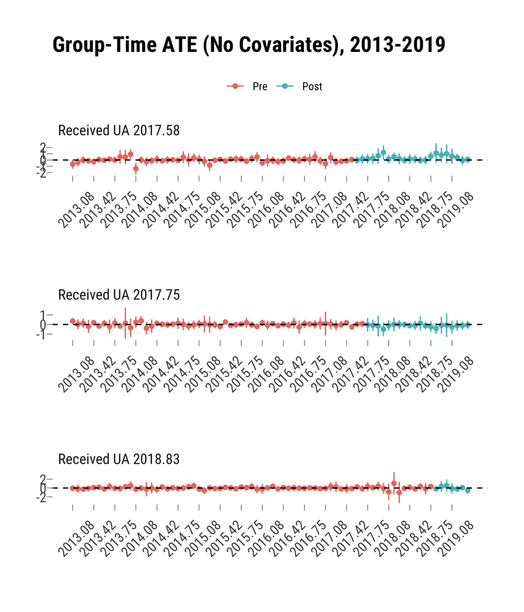

```r
ggdid(est_test,
      title = "Group-Time ATE (No Covariates), 2013-2019",
      grtitle = "Received UA",
      xgap = 12,
      theming = FALSE) +
  theme_ipsum_rc(grid = FALSE, ticks = TRUE) +
  theme(legend.position = "top",
        axis.text.x = element_text(angle = 45,
                                   margin = margin(t = 20)))
```

#### Dynamic Event Study w/ Plot (No Covariates)

This aggregates the group-time ATEs

```r
event_study <- aggte(est_test, type = "dynamic")

summary(event_study)
```

```
##
## Call:
## aggte(MP = est_test, type = "dynamic")
##
## Reference: Callaway, Brantly and Pedro H.C. Sant'Anna.  "Difference-in-Differences with Multiple Time Periods." Journal of Econometrics, Vol. 225, No. 2, pp. 200-230, 2021. <https://doi.org/10.1016/j.jeconom.2020.12.001>, <https://arxiv.org/abs/1803.09015>
##
##
## Overall summary of ATT's based on event-study/dynamic aggregation:
##     ATT    Std. Error     [ 95%  Conf. Int.]
##  0.1496        0.1278    -0.1008      0.4001
##
##
## Dynamic Effects:
##  Event time Estimate Std. Error [95% Simult.  Conf. Band]
##       -5.75  -0.0636     0.2007       -0.6322      0.5051
##       -5.66  -0.1482     0.2898       -0.9691      0.6727
##       -5.58  -0.2591     0.1793       -0.7669      0.2487
##       -5.50  -0.0713     0.1169       -0.4023      0.2597
##       -5.41   0.0940     0.0945       -0.1736      0.3616
##       -5.33   0.1596     0.0825       -0.0743      0.3934
##       -5.25  -0.2120     0.1187       -0.5483      0.1243
##       -5.16   0.3191     0.2635       -0.4274      1.0657
##       -5.08  -0.0521     0.0944       -0.3195      0.2153
##       -5.00  -0.1006     0.2299       -0.7519      0.5508
##       -4.91   0.2763     0.1366       -0.1106      0.6632
##       -4.83   0.5346     0.3419       -0.4338      1.5031
##       -4.75  -0.2648     0.2166       -0.8785      0.3488
##       -4.67   0.3562     0.0973        0.0807      0.6318 *
##       -4.66  -0.0357     0.1701       -0.5176      0.4462
##       -4.58  -0.1036     0.2883       -0.9204      0.7132
##       -4.50  -0.3089     0.1760       -0.8074      0.1896
##       -4.42  -0.1867     0.2303       -0.8392      0.4658
##       -4.41  -0.3126     0.1702       -0.7946      0.1695
##       -4.33   0.0918     0.1017       -0.1964      0.3800
##       -4.25  -0.1507     0.0669       -0.3402      0.0388
##       -4.17   0.1089     0.1097       -0.2018      0.4197
##       -4.16  -0.1526     0.1158       -0.4807      0.1755
##       -4.08  -0.0487     0.1007       -0.3340      0.2366
##       -4.00   0.0203     0.0874       -0.2274      0.2679
##       -3.92  -0.1483     0.1036       -0.4417      0.1451
```

[output cut: 81 more lines]

```
##        1.17   0.3745     0.2065       -0.2105      0.9594
##        1.25   0.7157     0.3860       -0.3776      1.8091
##        1.33  -0.2745     0.2223       -0.9043      0.3553
##        1.34   0.7924     0.3791       -0.2817      1.8664
##        1.42   0.6286     0.3773       -0.4402      1.6975
##        1.50   0.3587     0.2694       -0.4045      1.1219
##        1.58  -0.0407     0.1383       -0.4326      0.3511
##        1.59   0.3824     0.1786       -0.1235      0.8883
##        1.67  -0.0583     0.2330       -0.7184      0.6018
##        1.75   0.0707     0.1754       -0.4263      0.5677
## ---
## Signif. codes: `*' confidence band does not cover 0
##
## Control Group:  Not Yet Treated,  Anticipation Periods:  0
## Estimation Method:  Doubly Robust
```

Dynamic Event Study Plot (No Covariates)

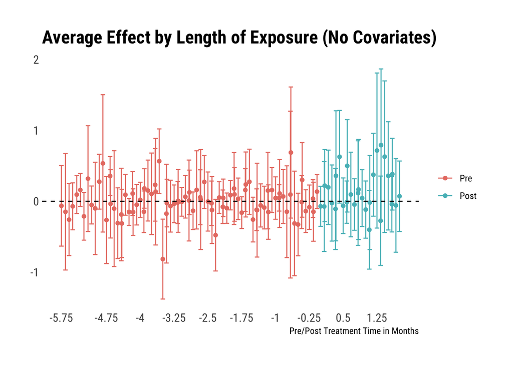

```r
ggdid(event_study,
      title = "Average Effect by Length of Exposure (No Covariates)",
      xlab = "Pre/Post Treatment Time in Months",
      xgap = 12,
      theming = FALSE) +
  theme_ipsum_rc(grid = F)
```

#### Overall Group Effects of Participating in Treatment (No Covariates)

```r
group_fx_no_covars <- aggte(est_test, type = "group")
summary(group_fx_no_covars)
```

```
##
## Call:
## aggte(MP = est_test, type = "group")
##
## Reference: Callaway, Brantly and Pedro H.C. Sant'Anna.  "Difference-in-Differences with Multiple Time Periods." Journal of Econometrics, Vol. 225, No. 2, pp. 200-230, 2021. <https://doi.org/10.1016/j.jeconom.2020.12.001>, <https://arxiv.org/abs/1803.09015>
##
##
## Overall summary of ATT's based on group/cohort aggregation:
##     ATT    Std. Error     [ 95%  Conf. Int.]
##  0.1482        0.1377    -0.1217      0.4182
##
##
## Group Effects:
##    Group Estimate Std. Error [95% Pointwise  Conf. Band]
##  2017.58   0.3602     0.2051         -0.0419      0.7622
##  2017.75  -0.1168     0.1871         -0.4835      0.2498
##  2018.83  -0.0106     0.2263         -0.4542      0.4330
## ---
## Signif. codes: `*' confidence band does not cover 0
##
## Control Group:  Not Yet Treated,  Anticipation Periods:  0
## Estimation Method:  Doubly Robust
```

Overall Group Effects Plot (No Covariates)

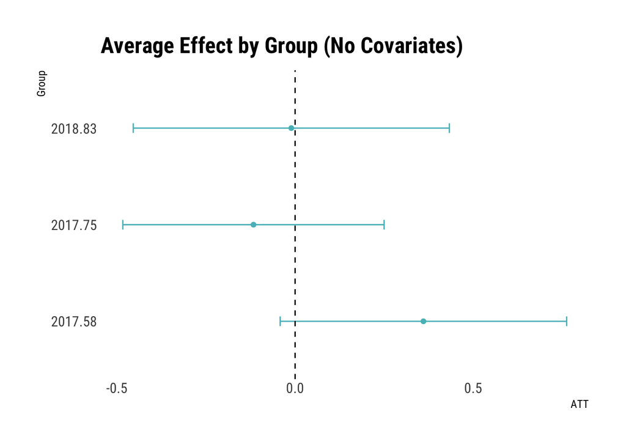

```r
ggdid(group_fx_no_covars,
      title = "Average Effect by Group (No Covariates)",
      theming = FALSE) +
  theme_ipsum_rc(grid = F) +
  theme(legend.position = "none")
```

### CS-DiD: With covariates

```r
est_w_covars <- att_gt(yname = "n_violations_per_1k_units",
                       gname = "treat_yr_mo_num",
                       idname = "zip",
                       tname = "inspection_yr_mo_num",
                       xformla = ~ evict_rate_17 + rs_rate_17 + pct_pov_17 + pct_wh_17,
                       data = violations_13_19,
                       control_group = "notyettreated",
                       allow_unbalanced_panel = TRUE,
                       est_method = "dr")
summary(est_w_covars)
```

```
##
## Call:
## att_gt(yname = "n_violations_per_1k_units", tname = "inspection_yr_mo_num",
##     idname = "zip", gname = "treat_yr_mo_num", xformla = ~evict_rate_17 +
##         rs_rate_17 + pct_pov_17 + pct_wh_17, data = violations_13_19,
##     allow_unbalanced_panel = TRUE, control_group = "notyettreated",
##     est_method = "dr")
##
## Reference: Callaway, Brantly and Pedro H.C. Sant'Anna.  "Difference-in-Differences with Multiple Time Periods." Journal of Econometrics, Vol. 225, No. 2, pp. 200-230, 2021. <https://doi.org/10.1016/j.jeconom.2020.12.001>, <https://arxiv.org/abs/1803.09015>
##
## Group-Time Average Treatment Effects:
##    Group    Time ATT(g,t) Std. Error [95% Simult.  Conf. Band]
##  2017.58 2013.08  -0.4625     0.2306       -1.1220      0.1969
##  2017.58 2013.17  -0.1656     0.2225       -0.8019      0.4706
##  2017.58 2013.25   0.2250     0.2442       -0.4734      0.9235
##  2017.58 2013.33  -0.1017     0.1503       -0.5316      0.3281
##  2017.58 2013.42  -0.1760     0.1815       -0.6952      0.3432
##  2017.58 2013.50   0.0051     0.1625       -0.4595      0.4697
##  2017.58 2013.58  -0.0374     0.1165       -0.3707      0.2958
##  2017.58 2013.67   0.1677     0.1068       -0.1378      0.4733
##  2017.58 2013.75  -0.1608     0.2035       -0.7427      0.4210
##  2017.58 2013.83   0.2949     0.3107       -0.5937      1.1836
##  2017.58 2013.92   0.4011     0.3449       -0.5852      1.3874
##  2017.58 2014.00   0.3002     0.4067       -0.8628      1.4631
##  2017.58 2014.08  -0.9412     0.3794       -2.0263      0.1439
##  2017.58 2014.17   0.1811     0.1858       -0.3502      0.7123
##  2017.58 2014.25   0.0722     0.2916       -0.7616      0.9061
##  2017.58 2014.33  -0.0659     0.1726       -0.5595      0.4278
##  2017.58 2014.42   0.1073     0.2172       -0.5138      0.7284
##  2017.58 2014.50  -0.1396     0.1252       -0.4977      0.2185
##  2017.58 2014.58   0.0622     0.2132       -0.5475      0.6719
##  2017.58 2014.67  -0.0385     0.1022       -0.3309      0.2538
##  2017.58 2014.75  -0.1297     0.1286       -0.4975      0.2380
##  2017.58 2014.83   0.1855     0.3077       -0.6944      1.0653
##  2017.58 2014.92   0.0151     0.3778       -1.0655      1.0957
##  2017.58 2015.00   0.1919     0.2597       -0.5507      0.9345
##  2017.58 2015.08  -0.0486     0.2309       -0.7088      0.6117
##  2017.58 2015.17   0.2179     0.3512       -0.7866      1.2224
##  2017.58 2015.25  -0.6825     0.2828       -1.4913      0.1263
##  2017.58 2015.33   0.0192     0.1236       -0.3342      0.3727
```

[output cut: 190 more lines]

```
##  2018.83 2018.58   0.3492     0.2974       -0.5014      1.1998
##  2018.83 2018.67  -0.1982     0.4347       -1.4415      1.0450
##  2018.83 2018.75   0.2864     0.1900       -0.2569      0.8297
##  2018.83 2018.83  -0.2384     0.1769       -0.7442      0.2674
##  2018.83 2018.92   0.3168     0.4503       -0.9709      1.6045
##  2018.83 2019.00   0.4984     0.4234       -0.7126      1.7093
##  2018.83 2019.08  -0.2038     0.3452       -1.1910      0.7834
##  2018.83 2019.17  -0.1987     0.2470       -0.9052      0.5078
##  2018.83 2019.25   0.0721     0.1993       -0.4978      0.6420
##  2018.83 2019.33  -0.4840     0.2367       -1.1608      0.1929
## ---
## Signif. codes: `*' confidence band does not cover 0
##
## Control Group:  Not Yet Treated,  Anticipation Periods:  0
## Estimation Method:  Doubly Robust
```

*228 rows*

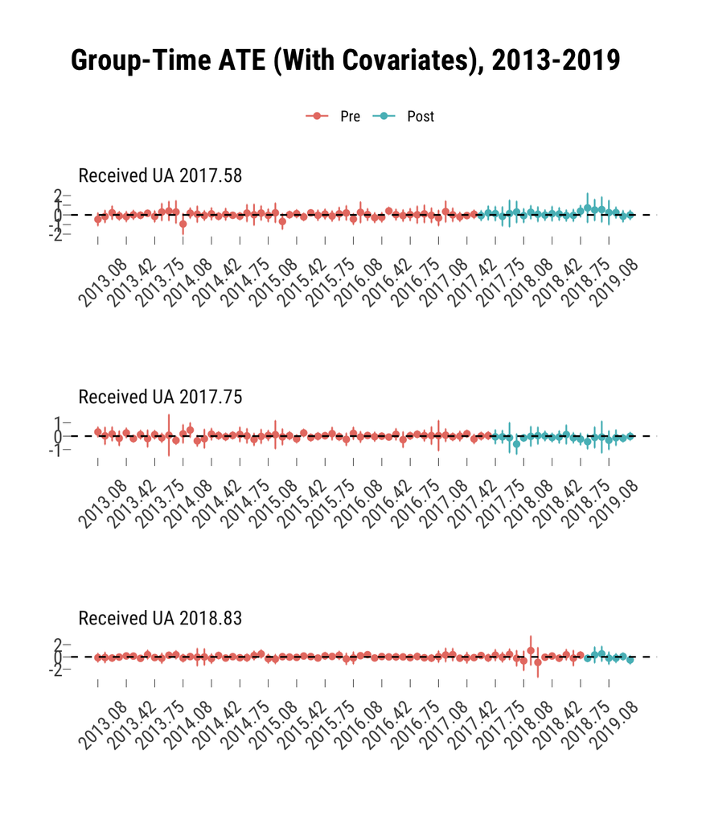

```r
ggdid(est_w_covars,
      title = "Group-Time ATE (With Covariates), 2013-2019",
      grtitle = "Received UA",
      xgap = 12,
      theming = FALSE) +
  theme_ipsum_rc(grid = FALSE, ticks = TRUE) +
  theme(legend.position = "top",
        axis.text.x = element_text(angle = 45,
                                   margin = margin(t = 20)))
```

```r
group_effects <- aggte(est_w_covars, type = "dynamic")
summary(group_effects)
```

```
##
## Call:
## aggte(MP = est_w_covars, type = "dynamic")
##
## Reference: Callaway, Brantly and Pedro H.C. Sant'Anna.  "Difference-in-Differences with Multiple Time Periods." Journal of Econometrics, Vol. 225, No. 2, pp. 200-230, 2021. <https://doi.org/10.1016/j.jeconom.2020.12.001>, <https://arxiv.org/abs/1803.09015>
##
##
## Overall summary of ATT's based on event-study/dynamic aggregation:
##     ATT    Std. Error     [ 95%  Conf. Int.]
##  0.0402        0.1183    -0.1916       0.272
##
##
## Dynamic Effects:
##  Event time Estimate Std. Error [95% Simult.  Conf. Band]
##       -5.75  -0.1288     0.2351       -0.8235      0.5659
##       -5.66  -0.1043     0.3087       -1.0163      0.8078
##       -5.58  -0.1852     0.1632       -0.6676      0.2971
##       -5.50  -0.0297     0.1103       -0.3555      0.2961
##       -5.41   0.1564     0.0935       -0.1197      0.4326
##       -5.33   0.1298     0.0860       -0.1243      0.3839
##       -5.25  -0.2376     0.1278       -0.6152      0.1401
##       -5.16   0.3611     0.2599       -0.4068      1.1290
##       -5.08  -0.1123     0.0920       -0.3841      0.1595
##       -5.00  -0.2221     0.2946       -1.0926      0.6484
##       -4.91   0.2640     0.1758       -0.2553      0.7833
##       -4.83   0.3420     0.2198       -0.3073      0.9914
##       -4.75  -0.1924     0.2268       -0.8625      0.4776
##       -4.67   0.3095     0.1128       -0.0238      0.6427
##       -4.66   0.0486     0.1457       -0.3819      0.4790
##       -4.58  -0.0142     0.2586       -0.7783      0.7499
##       -4.50  -0.1936     0.1757       -0.7127      0.3256
##       -4.42  -0.1612     0.2042       -0.7645      0.4421
##       -4.41  -0.2028     0.1595       -0.6742      0.2685
##       -4.33   0.2285     0.1181       -0.1204      0.5775
##       -4.25  -0.1452     0.0858       -0.3986      0.1082
##       -4.17   0.1085     0.1145       -0.2298      0.4468
##       -4.16  -0.1052     0.1230       -0.4686      0.2583
##       -4.08  -0.0774     0.0991       -0.3701      0.2152
##       -4.00  -0.0240     0.0772       -0.2521      0.2041
##       -3.92  -0.1246     0.1124       -0.4566      0.2075
```

[output cut: 81 more lines]

```
##        1.17   0.2244     0.1766       -0.2973      0.7461
##        1.25   0.4619     0.3719       -0.6369      1.5608
##        1.33  -0.3062     0.2516       -1.0497      0.4373
##        1.34   0.5054     0.3636       -0.5688      1.5797
##        1.42   0.3310     0.3269       -0.6350      1.2969
##        1.50   0.1071     0.2480       -0.6256      0.8397
##        1.58  -0.0173     0.1006       -0.3146      0.2801
##        1.59   0.2372     0.2014       -0.3580      0.8324
##        1.67  -0.1462     0.2113       -0.7706      0.4782
##        1.75  -0.0086     0.1598       -0.4809      0.4636
## ---
## Signif. codes: `*' confidence band does not cover 0
##
## Control Group:  Not Yet Treated,  Anticipation Periods:  0
## Estimation Method:  Doubly Robust
```

*117 rows*

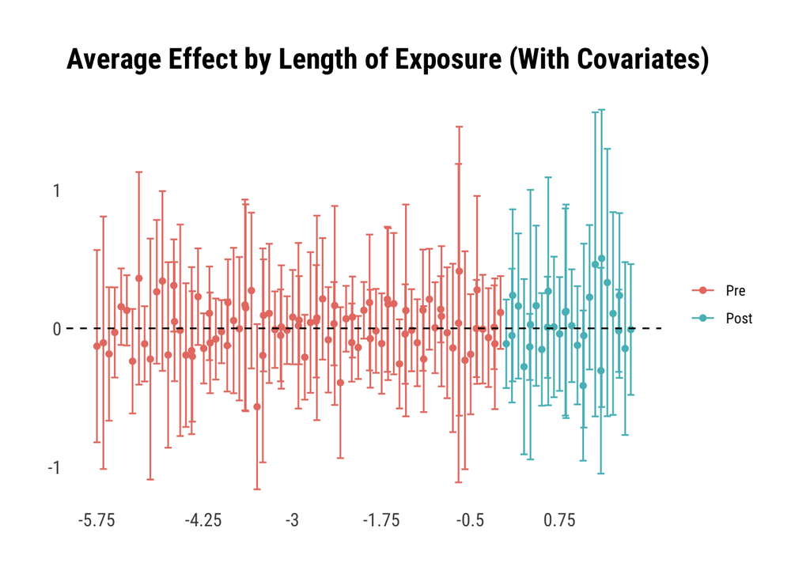

```r
ggdid(group_effects,
      title = "Average Effect by Length of Exposure (With Covariates)",
      xgap = 20,
      theming = FALSE) +
    theme_ipsum_rc(grid = FALSE)
```

```r
group_fx_w_covars <- aggte(est_w_covars, type = "group")
summary(group_fx_w_covars)
```

```
##
## Call:
## aggte(MP = est_w_covars, type = "group")
##
## Reference: Callaway, Brantly and Pedro H.C. Sant'Anna.  "Difference-in-Differences with Multiple Time Periods." Journal of Econometrics, Vol. 225, No. 2, pp. 200-230, 2021. <https://doi.org/10.1016/j.jeconom.2020.12.001>, <https://arxiv.org/abs/1803.09015>
##
##
## Overall summary of ATT's based on group/cohort aggregation:
##     ATT    Std. Error     [ 95%  Conf. Int.]
##  0.0362        0.1245    -0.2078      0.2803
##
##
## Group Effects:
##    Group Estimate Std. Error [95% Pointwise  Conf. Band]
##  2017.58   0.1523     0.2026         -0.2449      0.5495
##  2017.75  -0.1257     0.1436         -0.4071      0.1558
##  2018.83  -0.0340     0.2417         -0.5076      0.4397
## ---
## Signif. codes: `*' confidence band does not cover 0
##
## Control Group:  Not Yet Treated,  Anticipation Periods:  0
## Estimation Method:  Doubly Robust
```

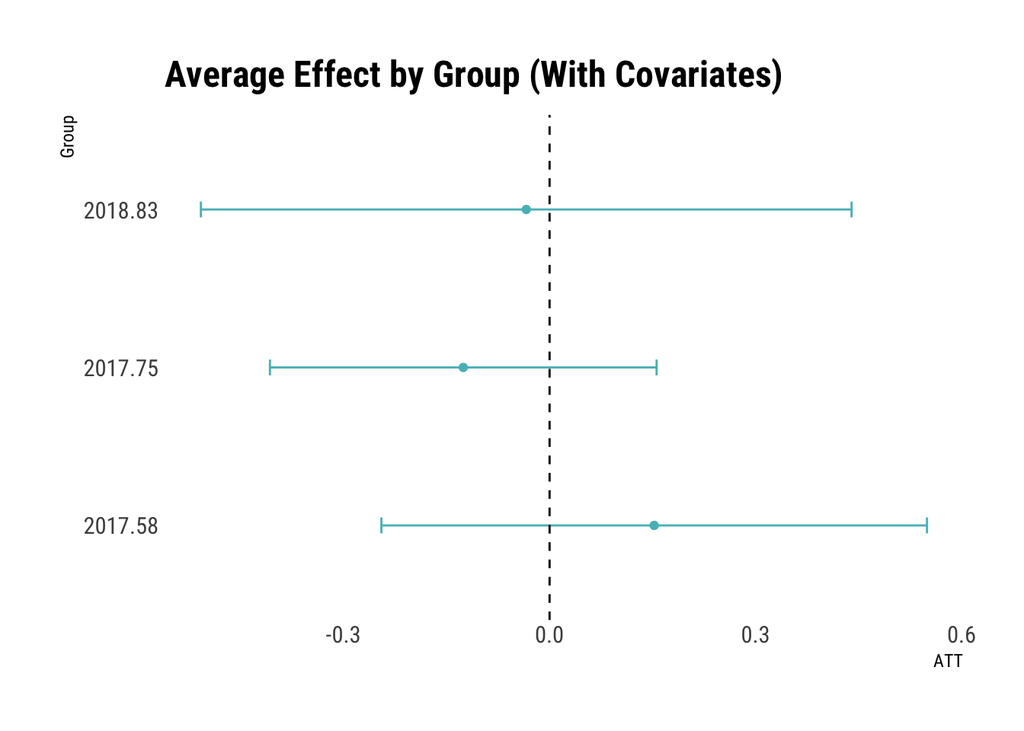

```r
ggdid(group_fx_w_covars,
      title = "Average Effect by Group (With Covariates)",
      theming = FALSE) +
  theme_ipsum_rc(grid = F) +
  theme(legend.position = "none")
```

### Aggregated Group Effects Comparison Tables

```r
t3a <- tidy(group_fx_no_covars) %>%
  select(-c(type, term, point.conf.low, point.conf.high)) %>%
  mutate(group = str_replace_all(group, c("Average" = "All Groups", "2017.58" = "Cohort 1", "2017.75" = "Cohort 2", "2018.83" = "Cohort 3")))

t3b <- tidy(group_fx_w_covars) %>%
  select(-c(type, term, point.conf.low, point.conf.high)) %>%
  mutate(group = str_replace_all(group, c("Average" = "All Groups", "2017.58" = "Cohort 1", "2017.75" = "Cohort 2", "2018.83" = "Cohort 3")))
```

```r
knitr::kables(
  list(
    kable(
      t3a,
      col.names = NULL,
      digits = 4,
      valign = 't') %>%
      add_header_above(c('Group', 'ATT', 'Std. Error', '95% Confidence Band' = 2)) %>%
      add_header_above(c(' ', 'Without Covariates' = 3)) %>%
      add_footnote(c("Signif. codes: '*' = confidence band does not cover 0", "Control Groups: Not Yet Treated, Anticipation Periods: 0", "Estimation Method: Doubly Robust"), notation = "none") %>%
      kable_styling(),
    kable(t3b,
          col.names = NULL,
          digits = 4,
          valign = 't') %>%
      add_header_above(c('Group', 'ATT', 'Std. Error', '95% Confidence Band' = 2)) %>%
      add_header_above(c(' ', 'With Covariates' = 3)) %>%
      kable_styling()
  ),
  caption = 'Table 3. Aggregated Group-Specific Treatment Effects'
) %>%
  kable_styling(full_width = F,
                  html_font = "Roboto Condensed")
```

Table 3. Aggregated Group-Specific Treatment Effects

| Group | Without Covariates ATT | Without Covariates Std. Error | Without Covariates 95% Confidence Band | 95% Confidence Band |
| --- | --- | --- | --- | --- |
| All Groups | 0.1482 | 0.1377 | -0.1217 | 0.4182 |
| Cohort 1 | 0.3602 | 0.2051 | -0.0419 | 0.7622 |
| Cohort 2 | -0.1168 | 0.1871 | -0.4835 | 0.2498 |
| Cohort 3 | -0.0106 | 0.2263 | -0.4542 | 0.4330 |

Signif. codes: ’*’ = confidence band does not cover 0  
Control Groups: Not Yet Treated, Anticipation Periods: 0  
Estimation Method: Doubly Robust

| Group | With Covariates ATT | With Covariates Std. Error | With Covariates 95% Confidence Band | 95% Confidence Band |
| --- | --- | --- | --- | --- |
| All Groups | 0.0362 | 0.1245 | -0.2078 | 0.2803 |
| Cohort 1 | 0.1523 | 0.2026 | -0.2449 | 0.5495 |
| Cohort 2 | -0.1257 | 0.1436 | -0.4071 | 0.1558 |
| Cohort 3 | -0.0340 | 0.2417 | -0.5076 | 0.4397 |

### ZIP-Level Parallel Trends “Test”

via [Callaway’s documentation](https://cran.r-project.org/web/packages/did/vignettes/pre-testing.html): “The did package contains an additional pre-test for the conditional parallel trends assumption in the conditional_did_pretest function.”

```r
cdp_wo_covars <- conditional_did_pretest(yname = "n_violations_per_1k_units",
                               tname = "inspection_yr_mo_num",
                               idname = "zip",
                               gname = "treat_yr_mo_num",
                               control_group = "notyettreated",
                               xformla = ~1,   # equivalent to NULL
                               data = violations_13_19)
summary(cdp_wo_covars)
```

```r
cdp_three_covars <- conditional_did_pretest(yname = "n_violations_per_1k_units",
                               tname = "inspection_yr_mo_num",
                               idname = "zip",
                               gname = "treat_yr_mo_num",
                               control_group = "notyettreated",
                               xformla = ~ evict_rate_17 + rs_rate_17 + pct_pov_17,
                               data = violations_13_19)
summary(cdp_three_covars)
```

```r
cdp_four_covars <- conditional_did_pretest(yname = "n_violations_per_1k_units",
                               tname = "inspection_yr_mo_num",
                               idname = "zip",
                               gname = "treat_yr_mo_num",
                               control_group = "notyettreated",
                               xformla = ~ evict_rate_17 + rs_rate_17 + pct_pov_17 + pct_wh_17,
                               data = violations_13_19)
summary(cdp_four_covars)
```

```r
cdp_three_table <- as.data.frame(do.call(cbind, cdp_three_covars)) %>%
  select(xformla, CvM, CvMcval, CvMpval) %>%
  distinct() %>%
  slice(2)

cdp_four_table <- as.data.frame(do.call(cbind, cdp_four_covars)) %>%
  select(xformla, CvM, CvMcval, CvMpval) %>%
  distinct() %>%
  slice(2)

cdp_table <- as.data.frame(do.call(cbind, cdp_wo_covars)) %>%
  select(xformla, CvM, CvMcval, CvMpval) %>%
  distinct() %>%
  slice(2) %>%
  bind_rows(cdp_three_table, cdp_four_table) %>%
  mutate(xformla = str_replace(xformla, "1\\b", "without covariates"))

cdp_table %>%
  kable(
    digits = 2,
    caption = 'Table 4. Cramer von Mises Test Results',
    col.names = c('Covariates', 'Test Statistic', 'Critical Value', 'P-Value'),
    align = "l") %>%
  add_footnote(c("Callaway and Sant'Anna propose the Cramer von Mises or Kolgorov-Smirnov-type integrated moments test as one tool for assessing whether the conditional parallel trends assumption might hold for all groups in all pre-treatment periods. See https://search.r-project.org/CRAN/refmans/did/html/conditional_did_pretest.html and Section 4 of Callaway & Sant'Anna (2020)."), notation = "none") %>%
    kable_styling(full_width = F, html_font = "Roboto Condensed")
```

[output not shown]

## Tract-Level Data Cleaning

See scripts/06_geocoding for detailed code that generates standard U.S. Census GEOIDs for most observations in our eviction dataset and violations dataset. Evictions, in particular, was incredibly messy; missing/uncoded observations stored separately. The geocoding is very memory-intensive, so here’s a shortcut to load the resulting data.

```r
geocoded_vio <- read_csv("../data_build/geocoded_violation_addresses.csv") %>%
  select(address, geoid)

rtc_zips <- read_csv("../data_build/rtc_zip_rollout.csv") %>% # Source: Ellen et al (2021), "Early Evidence on Eviction Patterns", pg.8 footnotes
  clean_names() %>%
  mutate(zip = as.numeric(zip)) %>%
  rename(rtc_treat_date = date_added) %>%
  select(cohort, rtc_treat_date, zip)
tract_zip_assignments <- read_csv("../data_build/tb_tract_zip_assignments.csv") %>%
  clean_names() %>%
  filter(res_ratio > 0) %>%   # SL added in March, since several tracts had no residential addresses in a given zip
  select(zip, tract) %>%
  rename (geoid = tract) %>%
  left_join(rtc_zips, by = "zip") %>%
  mutate(
    cohort = replace_na(cohort, 5),
    rtc_treat_date = replace_na(rtc_treat_date, as_date("2021-05-11")),
    geoid = as.character(geoid)
    ) %>%
  rename(tract_treat_zip = zip)

geocoded_ev <- read_csv("../data_build/geocoded_evictions.csv") %>%
  select(address, geoid) %>%
  mutate(geoid = as.character(geoid))

geocoded_rs <- read_csv("../data_build/rs17_tract_counts.csv") %>%
  clean_names() %>%
  mutate(geoid = as.character(geoid))

acs <- read_csv("../data_build/acs5_tracts_12_23_renter_occ_units.csv") %>%
  clean_names() %>%
  select(!name) %>%
  mutate(geoid = as.character(geoid))

acs_missing <- acs %>%
  select(year, geoid, tot_units, tot_vac_units, tot_occ_units, renter_occ_units, tot_pop_rou, tot_wh_rou, pct_wh_rou, tot_hh, tot_hh_pov, pct_pov) %>%
  filter(if_any(everything(), is.na)) %>%
  arrange(geoid, year) # 544 of 19,663 contain missing obs

geoid_acs_count <- acs_missing %>%
  group_by(geoid) %>%
  summarize(n_rou = sum(renter_occ_units))  # 112 geoids show "NA" for pop covariate estimates bc they have zero renter-occ housing
```

Generate tract-level eviction counts

```r
evictions <- read_csv("../data_raw/evictions_2017.csv") %>%
  mutate(address = normal_address(eviction_address)) %>%
  mutate(
    address = str_replace_all(address, "STREE T|S TREET|STRE ET|ST REET|STR EET|STREE(?=[:punct:])",
                              "ST"),
    address = str_replace_all(address, "A VENUE|AV ENUE|AVE NUE|AVEN UE|AVENU E|AV ENUE|AV |AVE ",
                              "AVE"),
    address = str_replace_all(address, "P ARKWAY|PA RKWAY|PAR KWAY|PARKW AY|PKWY",
                              "PKWY"),
    address = str_replace_all(address, "CONC OURSE",
                              "CONCOURSE")) %>%
  left_join(geocoded_ev, by = "address") %>%     # 13,601 obs of 10 variables
  group_by(geoid) %>%
  summarize(evictions_per_tract = n_distinct(docket_number)) # 1,829 obs of 2 variables
```

Generate tract-level violation counts

```r
analyze <- read_csv("../data_build/cleaner_utility_violations.csv.gz") %>%
  mutate(year = year(inspection_yr_mo)) %>%
  mutate(address = paste(housenumber, streetname), .after = zip) %>%
  mutate(
    address = str_replace_all(address, "HOR HARDING EXPRESSWAY SR NORTH",
                              "HORACE HARDING EXPY"),
    address = str_replace_all(address, "HOR HARDING EXPRESSWAY SR SOUTH",
                              "HORACE HARDING EXPY"),
    address = str_replace_all(address, "ST NICHOLAS PLACE",
                              "SAINT NICHOLAS PL"),
    address = str_replace_all(address, "(?<=[:space:])9 AVENUE",
                              "9TH AVENUE"),
    address = str_replace_all(address, "WEST 181 STREET",
                              "W 181ST ST"),
    address = str_replace_all(address, "FREDERICK DOUGAL",
                              "FREDERICK DOUGLASS"),
    address = str_replace_all(address, "MANH(?=[:space:])",
                              "MANHATTAN"),
    address = str_replace_all(address, "EAST 6(?=[:space:])",
                              "EAST 6TH"),
    address = str_replace_all(address, "EAST 6(?=[:space:])",
                              "EAST 6TH"),
    address = str_replace_all(address, "EAST 12(?=[:space:])",
                              "EAST 12TH"),
    address = str_replace_all(address, "EAST 13(?=[:space:])",
                              "EAST 13TH"),
    address = str_replace_all(address, "EAST 14(?=[:space:])",
                              "EAST 14TH"),
    address = str_replace_all(address, "EAST 15(?=[:space:])",
                              "EAST 15TH"),
    address = str_replace_all(address, "EAST 31(?=[:space:])",
                              "EAST 31ST"),
    address = str_replace_all(address, "EAST 39(?=[:space:])",
                              "EAST 39TH"),
    address = str_replace_all(address, "EAST 57(?=[:space:])",
                              "EAST 57TH"),
    address = str_replace_all(address, "EAST 132(?=[:space:])",
                              "EAST 132ND"),
    address = str_replace_all(address, "EAST 174(?=[:space:])",
                              "EAST 174TH"),
    address = str_replace_all(address, "EAST 176(?=[:space:])",
                              "EAST 176TH"),
    address = str_replace_all(address, "EAST 187(?=[:space:])",
                              "EAST 187TH"),
    address = str_replace_all(address, "EAST 238(?=[:space:])",
                              "EAST 238TH"),
    address = str_replace_all(address, "MC BRIDE",
                              "MCBRIDE"),
    address = str_replace_all(address, "ADAM C POWELL BOULEVARD",
                              "ADAM CLAYTON POWELL JR BLVD"),
    address = str_replace_all(address, "ADAM C POWELL JR BOULEVARD",
                              "ADAM CLAYTON POWELL JR BLVD"),
    address = str_replace_all(address, "HUTCH RIVER",
                              "HUTCHINSON RIVER"),
    address = str_replace_all(address, "AVENUE",
                              "AVE"),
    address = str_replace_all(address, "STREET",
                              "ST"),
    address = str_replace_all(address, "PARKWAY",
                              "PKWY"),
    address = str_replace_all(address, "BOULEVARD",
                              "BLVD")) %>%
  left_join(geocoded_vio, by = "address") %>%     # adds geoid to each violation
#  left_join(tract_zip_assignments, by = "geoid") %>%    # adds treatment date to each violation
 group_by(geoid, inspection_yr_mo) %>%
  summarize(n_violations = n_distinct(violationid, na.rm = F)) %>%
  ungroup() %>%
  complete(geoid, inspection_yr_mo, fill = list(n_violations = 0)) # expand all 12 annual yearmonth observations for all zip codes, even if no violations reported
```

Merge tract-level covariates for analysis

```r
analyze <- analyze %>%
  mutate(year = year(inspection_yr_mo),
         geoid = as.character(geoid)) %>%
  group_by(geoid, inspection_yr_mo) %>%
  left_join(acs, by = c("year", "geoid")) %>%   # Census covariates
  left_join(evictions, by = "geoid") %>%
  left_join(geocoded_rs, by = "geoid") %>%
  mutate(n_violations_per_1k_units = ((n_violations/renter_occ_units)*1000), .after = n_violations) %>%
  ungroup() %>%
  group_by(geoid) %>%
  mutate(
    evict_rate_17 = case_when(
      year == 2017 ~ (evictions_per_tract/renter_occ_units)),   # eviction rate
    rs_rate_17 = case_when(
      year == 2017 ~ (rs_17_count/renter_occ_units)),   # rent stabilization rate
    pct_pov_17 = case_when(
      year == 2017 ~ pct_pov),   # poverty rate
    pct_wh_17 = case_when(
      year == 2017 ~ pct_wh_rou),   # time-invariant control for baseline POC residents at treatment selection year
    pct_bl_17 = case_when(
      year == 2017 ~ pct_bl_rou)   # time-invariant control for baseline POC residents at treatment selection year
     ) %>%
  fill(evict_rate_17, rs_rate_17, pct_pov_17, pct_wh_17, pct_bl_17, .direction = "updown") %>%
  select(-year) %>%
  ungroup() %>%
  mutate(
    n_violations_per_1k_units = ifelse(
      is.infinite(n_violations_per_1k_units), NA, n_violations_per_1k_units)
    ) %>%
  mutate(med_yr_blt_rou = na_if(med_yr_blt_rou, 0))
```

Generate RTC Treatment Status Indicator

```r
analyze <- analyze %>%
  left_join(tract_zip_assignments, by = "geoid")
```

```r
analyze <- analyze %>%
  left_join(tract_zip_assignments, by = "geoid")   # 152,999 obs of 41 variables
```

Save

```r
write_csv(analyze, "../data_build/tract_set_for_analysis.csv.gz")
```

## Tract-Level Summary Stats

```r
violations <- read_csv("../data_build/tract_set_for_analysis.csv.gz")
```

Adjust data storage to work with did package

```r
violations <- violations %>%
  mutate(inspection_yr_mo = as.yearmon(inspection_yr_mo),
         treat_yr_mo = as.yearmon(rtc_treat_date)) %>%   # via zoo package, gives evenly-spaced yearmonth increments where january is year.00, feb is year.1/12, march is year.2/12, etc
  mutate(inspection_yr_mo_num = round(as.numeric(inspection_yr_mo), digits = 2), .after = inspection_yr_mo) %>%
  mutate(treat_yr_mo_num = round(as.numeric(treat_yr_mo), digits = 2), .after = treat_yr_mo) %>%
  mutate(treat_yr_mo_zero = case_when(   # CS-DiD documentation recommends recoding cases never treated during study period (here, Cohorts 4 + 5) as "0"
    treat_yr_mo == "May 2021" ~ as.numeric(0),
    treat_yr_mo == "Dec 2019" ~ as.numeric(0),
    TRUE ~ treat_yr_mo_num)) %>%      # 160,391 obs. of 44 variables
  mutate_all(~ifelse(is.nan(.), NA, .)) %>%
  mutate_all(~ifelse(is.infinite(.), NA, .))  # converts NaN & infinite values to NA, since -did- package can't parse the former as the latter
```

Table 1 (Tract-Level)

```r
labels = c("Total violations",
           "Violations per 1k units",
           "Total housing units",
           "Total vacant housing units",
           "% vacant housing units",
           "Total occupied housing units",
           "Total renter-occupied units",
           "% housing units renter-occupied",
           "Renter population",
           "Median renter hh income",
           "Median renter hh inc in 2020 USD",
           "Median year built",
           "Median year moved into unit",
           "Median gross rent",
           "Median gross rent in 2020 USD",
           "Median rent burden",
           "Total renter householders with college degree",
           "% renter householders with college degree",
           "Total white renter householders",
           "% white renter householders",
           "Total Black renter householders",
           "% Black renter householders",
           "Total Asian renter householders",
           "% Asian renter householders",
           "Total Hispanic/Latinx renter householders",
           "% Hispanic/Latinx renter householders",
           "Total households",
           "Total hh below Federal poverty line",
           "% hh below Federal poverty line",
           "Total evictions in 2017",
           "Total rent-stabilized units in 2017",
           "% renter-occupied unit evictions in 2017",
           "% renter-occupied units rent-stabilized in 2017",
           "% hh below Federal poverty line in 2017",
           "% white renter householders in 2017",
           "% Black renter householders in 2017")

violations %>%
  ungroup() %>%
  mutate(cohort = factor(cohort)) %>%
  select(-c(geoid, inspection_yr_mo_num, tract_treat_zip, inspection_yr_mo, rtc_treat_date, treat_yr_mo, treat_yr_mo_num, treat_yr_mo_zero)) %>%
  st(group = 'cohort',
     group.test = T,
     col.align = 'center',
     labels = labels,
     title = 'Table 1. Summary Statistics by Tract-Level RTC Treatment Cohort: NYC Renter-Occupied Units, January 2013 - May 2019',
     out = 'kable') %>%
  kable_styling(full_width = F,
                html_font = "Roboto Condensed",
                bootstrap_options = c("condensed", "striped"))
```

Table 1. Summary Statistics by Tract-Level RTC Treatment Cohort: NYC Renter-Occupied Units, January 2013 - May 2019

| cohort Variable | 1 N | 1 Mean | 1 SD | 2 N | 2 Mean | 2 SD | 3 N | 3 Mean | 3 SD | 4 N | 4 Mean | 4 SD | 5 N | 5 Mean | 5 SD | Test |
| --- | --- | --- | --- | --- | --- | --- | --- | --- | --- | --- | --- | --- | --- | --- | --- | --- |
| Total violations | 10164 | 1.3 | 2.2 | 6083 | 0.85 | 1.8 | 6391 | 1 | 2.1 | 5698 | 1.5 | 2.5 | 124432 | 0.57 | 1.6 | F=824.952*** |
| Violations per 1k units | 10164 | 1.4 | 3.1 | 6083 | 0.56 | 1.3 | 6391 | 0.76 | 1.6 | 5698 | 1.3 | 2.4 | 124326 | 0.64 | 2.9 | F=214.263*** |
| Total housing units | 10164 | 1585 | 835 | 6083 | 2148 | 1129 | 6391 | 1655 | 776 | 5698 | 1802 | 874 | 124432 | 1640 | 1150 | F=340.015*** |
| Total vacant housing units | 10164 | 148 | 107 | 6083 | 169 | 168 | 6391 | 130 | 86 | 5698 | 140 | 89 | 124432 | 153 | 196 | F=45.835*** |
| % vacant housing units | 10164 | 0.11 | 0.061 | 6083 | 0.083 | 0.051 | 6391 | 0.089 | 0.051 | 5698 | 0.094 | 0.055 | 124338 | 0.1 | 0.088 | F=109.459*** |
| Total occupied housing units | 10164 | 1437 | 778 | 6083 | 1979 | 1009 | 6391 | 1526 | 725 | 5698 | 1662 | 833 | 124432 | 1487 | 1012 | F=413.019*** |
| Total renter-occupied units | 10164 | 1101 | 767 | 6083 | 1361 | 914 | 6391 | 1190 | 725 | 5698 | 1429 | 850 | 124432 | 980 | 843 | F=749.567*** |
| % housing units renter-occupied | 10164 | 0.72 | 0.24 | 6083 | 0.67 | 0.27 | 6391 | 0.74 | 0.19 | 5698 | 0.83 | 0.17 | 124338 | 0.62 | 0.24 | F=1687.929*** |
| Renter population | 10164 | 2918 | 1961 | 6083 | 3508 | 2165 | 6391 | 3233 | 1944 | 5698 | 3883 | 2304 | 124432 | 2448 | 1961 | F=1326.473*** |
| Median renter hh income | 9767 | 36404 | 13039 | 5965 | 46965 | 17219 | 6314 | 45669 | 13128 | 5554 | 32127 | 13737 | 120601 | 51866 | 27696 | F=1569.367*** |
| Median renter hh inc in 2020 USD | 9767 | 38953 | 13699 | 5965 | 50303 | 18225 | 6314 | 48846 | 13494 | 5554 | 34389 | 14570 | 120601 | 55527 | 29407 | F=1600.379*** |
| Median year built | 9265 | 1952 | 15 | 5556 | 1953 | 14 | 5401 | 1943 | 9 | 5289 | 1954 | 13 | 113923 | 1952 | 19 | F=341.905*** |
| Median year moved into unit | 10140 | 2007 | 3.3 | 6059 | 2007 | 3.5 | 6391 | 2007 | 3.2 | 5686 | 2006 | 3.4 | 123463 | 2007 | 3.6 | F=154.263*** |
| Median gross rent | 10152 | 1190 | 268 | 6083 | 1351 | 261 | 6391 | 1300 | 146 | 5698 | 1127 | 301 | 123836 | 1422 | 432 | F=1502.717*** |
| Median gross rent in 2020 USD | 10152 | 1275 | 279 | 6083 | 1447 | 270 | 6391 | 1392 | 137 | 5698 | 1207 | 316 | 123836 | 1522 | 454 | F=1564.142*** |
| Median rent burden | 10164 | 36 | 7.2 | 6083 | 35 | 7 | 6391 | 34 | 5.9 | 5698 | 37 | 7.1 | 124112 | 34 | 7.7 | F=425.715*** |
| Total renter householders with college degree | 10164 | 274 | 299 | 6083 | 490 | 598 | 6391 | 313 | 245 | 5698 | 313 | 327 | 124432 | 382 | 564 | F=206.097*** |
| % renter householders with college degree | 10164 | 0.22 | 0.14 | 6083 | 0.31 | 0.18 | 6391 | 0.25 | 0.098 | 5698 | 0.2 | 0.15 | 124326 | 0.34 | 0.23 | F=1399.084*** |
| Total white renter householders | 10164 | 133 | 171 | 6083 | 363 | 528 | 6391 | 254 | 211 | 5698 | 167 | 258 | 124432 | 373 | 556 | F=730.69*** |
| % white renter householders | 10164 | 0.1 | 0.11 | 6083 | 0.29 | 0.27 | 6391 | 0.27 | 0.21 | 5698 | 0.1 | 0.15 | 124326 | 0.36 | 0.31 | F=2796.841*** |
| Total Black renter householders | 10164 | 568 | 539 | 6083 | 339 | 441 | 6391 | 464 | 540 | 5698 | 551 | 338 | 124432 | 210 | 343 | F=3679.213*** |
| % Black renter householders | 10164 | 0.56 | 0.24 | 6083 | 0.22 | 0.26 | 6391 | 0.31 | 0.3 | 5698 | 0.44 | 0.22 | 124326 | 0.24 | 0.3 | F=3218.795*** |
| Total Asian renter householders | 10164 | 40 | 72 | 6083 | 183 | 211 | 6391 | 52 | 56 | 5698 | 54 | 95 | 124432 | 114 | 207 | F=811.287*** |
| % Asian renter householders | 10164 | 0.031 | 0.042 | 6083 | 0.16 | 0.19 | 6391 | 0.046 | 0.048 | 5698 | 0.03 | 0.043 | 124326 | 0.12 | 0.15 | F=1904.71*** |
| Total Hispanic/Latinx renter householders | 10164 | 383 | 386 | 6083 | 491 | 514 | 6391 | 432 | 347 | 5698 | 692 | 596 | 124432 | 282 | 381 | F=2014.659*** |
| % Hispanic/Latinx renter householders | 10164 | 0.32 | 0.23 | 6083 | 0.34 | 0.26 | 6391 | 0.38 | 0.19 | 5698 | 0.45 | 0.21 | 124326 | 0.27 | 0.23 | F=1344.136*** |
| Total households | 10164 | 1437 | 778 | 6083 | 1979 | 1009 | 6391 | 1526 | 725 | 5698 | 1662 | 833 | 124432 | 1487 | 1012 | F=413.019*** |
| Total hh below Federal poverty line | 10164 | 370 | 246 | 6083 | 368 | 272 | 6391 | 291 | 191 | 5698 | 515 | 306 | 124432 | 262 | 243 | F=2013.738*** |
| % hh below Federal poverty line | 10164 | 0.25 | 0.11 | 6083 | 0.19 | 0.099 | 6391 | 0.19 | 0.072 | 5698 | 0.31 | 0.11 | 124338 | 0.18 | 0.12 | F=2572.456*** |
| Total evictions in 2017 | 10087 | 10 | 8.4 | 5852 | 9.2 | 9.1 | 6006 | 9.9 | 7.5 | 5467 | 13 | 7.5 | 108031 | 6.6 | 7.1 | F=1809.387*** |
| Total rent-stabilized units in 2017 | 8470 | 553 | 496 | 5159 | 849 | 613 | 6083 | 650 | 593 | 5390 | 641 | 657 | 103180 | 476 | 572 | F=716.078*** |
| % renter-occupied unit evictions in 2017 | 10087 | 0.012 | 0.011 | 5852 | 0.0071 | 0.0054 | 6006 | 0.0085 | 0.0056 | 5467 | 0.01 | 0.0061 | 108031 | 0.0085 | 0.0086 | F=540.852*** |
| % renter-occupied units rent-stabilized in 2017 | 8470 | 0.41 | 0.24 | 5159 | 0.51 | 0.29 | 6083 | 0.46 | 0.28 | 5390 | 0.38 | 0.28 | 103180 | 0.38 | 0.32 | F=285.267*** |
| % hh below Federal poverty line in 2017 | 10164 | 0.25 | 0.11 | 6083 | 0.19 | 0.1 | 6391 | 0.18 | 0.067 | 5698 | 0.32 | 0.12 | 124355 | 0.18 | 0.12 | F=2840.045*** |
| % white renter householders in 2017 | 10164 | 0.11 | 0.12 | 6083 | 0.29 | 0.26 | 6391 | 0.28 | 0.21 | 5698 | 0.11 | 0.15 | 124355 | 0.35 | 0.31 | F=2616.051*** |
| % Black renter householders in 2017 | 10164 | 0.54 | 0.24 | 6083 | 0.21 | 0.25 | 6391 | 0.3 | 0.29 | 5698 | 0.44 | 0.22 | 124355 | 0.24 | 0.3 | F=3097.992*** |

Statistical significance markers: * p<0.1; ** p<0.05; *** p<0.01

Table 2. Number of Months Treated, by RTC Cohort

```r
violations %>%
  mutate(
    treated = case_when(
      treat_yr_mo > inspection_yr_mo ~ 0,
      TRUE ~ 1)) %>%
  filter(!is.na(cohort)) %>%
  group_by(cohort, treated) %>%
  summarize(n_months_treated = n_distinct(inspection_yr_mo),
            n_tracts = n_distinct(geoid)) %>%
  pivot_wider(names_from = treated, values_from = n_months_treated) %>%
  mutate(rtc_date = case_when(
    cohort == 1 ~ "Aug. 2017",
    cohort == 2 ~ "Oct. 2017",
    cohort == 3 ~ "Nov. 2018",
    cohort == 4 ~ "Dec. 2019",
    cohort == 5 ~ "May 2021"),
    .after = cohort) %>%
  replace(is.na(.), 0) %>%
  #adorn_totals(,,,, n_tracts) %>%
  kable(
    caption = 'Table 2. NYC Right-to-Counsel Treatment Waves Observed in 2013 - 2019 Study Period',
    col.names = c('Wave', 'RTC Treatment Date', 'Tracts Treated', 'Months Observed Pre-Treatment', 'Months Observed Post-Treatment'),
    align = "c") %>%
    kable_styling(full_width = F, html_font = "Roboto Condensed")
```

Table 2. NYC Right-to-Counsel Treatment Waves Observed in 2013 - 2019 Study Period

| Wave | RTC Treatment Date | Tracts Treated | Months Observed Pre-Treatment | Months Observed Post-Treatment |
| --- | --- | --- | --- | --- |
| 1 | Aug. 2017 | 132 | 55 | 22 |
| 2 | Oct. 2017 | 79 | 57 | 20 |
| 3 | Nov. 2018 | 83 | 70 | 7 |
| 4 | Dec. 2019 | 74 | 77 | 0 |
| 5 | May 2021 | 1616 | 77 | 0 |

How many tracts per treatment wave?

```r
violations %>%
  group_by(cohort) %>%
  summarize(tracts = n_distinct(geoid, na.rm = T))
```

```
## # A tibble: 6 × 2
##   cohort tracts
##    <dbl>  <int>
## 1      1    132
## 2      2     79
## 3      3     83
## 4      4     74
## 5      5   1616
## 6     NA      2
```

Table 3. Key Covariate Summaries, by Cohort (to highlight heterogeneity)

```r
violations %>%
  filter(!is.na(cohort)) %>%
  group_by(cohort) %>%
  summarize(
    #violations = sum(n_violations),
    tracts = n_distinct(geoid, na.rm = TRUE),
            violation_rate = mean(n_violations_per_1k_units, na.rm = TRUE),
            evict_rate = mean(evict_rate_17, na.rm = TRUE),
            rs_rate = mean(rs_rate_17, na.rm = TRUE),
            pct_pov = (mean(pct_pov_17, na.rm = TRUE)*100),
            #hh_inc = mean(med_hh_inc_rou_2020_adj, na.rm = TRUE),
            rent_burden = mean(med_rent_burden, na.rm = TRUE),
            yr_blt = mean(med_yr_blt_rou, na.rm = TRUE),
            pct_college_grads = (mean(pct_college_deg_rou, na.rm = TRUE)*100),
            pct_wh = (mean(pct_wh_rou, na.rm = TRUE)*100),
            pct_bl = (mean(pct_bl_rou, na.rm = TRUE)*100),
            pct_asn = (mean(pct_asn_rou, na.rm = TRUE)*100),
            pct_ltx = (mean(pct_ltx_rou, na.rm = TRUE)*100)
            ) %>%
  knitr::kable(digits = 2,
               caption = 'Table 3. Selected Potential Covariates by RTC Treatment Cohort: NYC Renter-Occupied Units, January 2013 - May 2019',
               col.names = c("Treatment Cohort", "Residential Census Tracts", "Avg Monthly Violations per 1k Units", "2017 Eviction Rate", "2017 Rent Stabilization Rate", "2017 Poverty Rate", "Rent Burden", "Median Year Built", "Percent College Graduates", "Percent White", "Percent Black", "Percent Asian", "Percent Latinx"),
               align = "c") %>%
  kable_styling(full_width = F, html_font = "Roboto Condensed")
```

Table 3. Selected Potential Covariates by RTC Treatment Cohort: NYC Renter-Occupied Units, January 2013 - May 2019

| Treatment Cohort | Residential Census Tracts | Avg Monthly Violations per 1k Units | 2017 Eviction Rate | 2017 Rent Stabilization Rate | 2017 Poverty Rate | Rent Burden | Median Year Built | Percent College Graduates | Percent White | Percent Black | Percent Asian | Percent Latinx |
| --- | --- | --- | --- | --- | --- | --- | --- | --- | --- | --- | --- | --- |
| 1 | 132 | 1.36 | 0.01 | 0.41 | 24.66 | 35.97 | 1952.11 | 22.13 | 10.47 | 55.71 | 3.13 | 32.30 |
| 2 | 79 | 0.56 | 0.01 | 0.51 | 19.19 | 35.08 | 1953.47 | 30.95 | 28.84 | 21.86 | 16.18 | 33.84 |
| 3 | 83 | 0.76 | 0.01 | 0.46 | 17.81 | 33.67 | 1943.21 | 24.96 | 26.91 | 30.64 | 4.56 | 38.38 |
| 4 | 74 | 1.27 | 0.01 | 0.38 | 31.77 | 37.13 | 1953.63 | 19.96 | 10.48 | 44.14 | 3.04 | 44.68 |
| 5 | 1616 | 0.64 | 0.01 | 0.38 | 17.62 | 33.91 | 1952.27 | 33.94 | 35.83 | 24.41 | 12.00 | 26.88 |

## Tract-Level Analysis

Callaway & Sant’Anna’s package requires time and treatment periods to be stored as numeric variables, and never-treated groups should be assigned treatment period “0”.

```r
violations %>%
  ungroup() %>%
  group_by(cohort) %>%
  summarize(max_vios = max(n_violations, na.rm = T),
            max_per_1k = max(n_violations_per_1k_units, na.rm = T),
            mean_per_1k = mean(n_violations_per_1k_units, na.rm = T))
```

```
## # A tibble: 6 × 4
##   cohort max_vios max_per_1k mean_per_1k
##    <dbl>    <dbl>      <dbl>       <dbl>
## 1      1       23       76.9       1.36
## 2      2       31       32.4       0.561
## 3      3       29       22.2       0.760
## 4      4       28       43.2       1.27
## 5      5       83      500         0.642
## 6     NA       13        0         0
```

empties <- violations %>% # violation rate missing values filter(is.na(n_violations_per_1k_units)) # 325 of 160,391 () empties %>% group_by(geoid) %>% summarize(records = n()) # 77 tracts are missing n_violations_per_1k units

empties <- violations %>%  
filter(is.na(evict_rate_17)) # 17,556 of 160,391 missing eviction rate empties %>% group_by(geoid) %>% summarize(records = n()) # 228 tracts missing eviction rate

empties <- violations %>%  
filter(is.na(rs_rate_17)) # 24,717 obs missing rent stabilization rate empties %>% group_by(geoid) %>% summarize(records = n()) # 321 tracts missing rent stabilization rate

Identify non-residential census tracts

violations %>% group_by(geoid) %>% distinct(geoid) # 1,987 tracts

violations %>% group_by(geoid) %>% filter(inspection_yr_mo >= 2017, inspection_yr_mo < 2018, tot_units > 0) %>% distinct(geoid) # 4 non-residential tracts contained zero housing units in 2017; 1,983 were residential.

### CS-DiD by Tract: No Covariates

```r
est_test <- att_gt(yname = "n_violations_per_1k_units",
                   gname = "treat_yr_mo_zero",      # year-month first treated
                   idname = "geoid",
                   tname = "inspection_yr_mo_num",  # year-month time periods
                   xformla = ~1,
                   data = violations,
                   allow_unbalanced_panel = TRUE,   # prevents model from forcibly balancing panel by dropping observations
                   control_group = "notyettreated", # controls are both not-yet-treated within 2013-2019 (Cohorts 2 & 3) and never-treated until after 2019 (Cohorts 4 & 5)
                   est_method = "dr")   # doubly-robust standard errors
summary(est_test)
```

```
##
## Call:
## att_gt(yname = "n_violations_per_1k_units", tname = "inspection_yr_mo_num",
##     idname = "geoid", gname = "treat_yr_mo_zero", xformla = ~1,
##     data = violations, allow_unbalanced_panel = TRUE, control_group = "notyettreated",
##     est_method = "dr")
##
## Reference: Callaway, Brantly and Pedro H.C. Sant'Anna.  "Difference-in-Differences with Multiple Time Periods." Journal of Econometrics, Vol. 225, No. 2, pp. 200-230, 2021. <https://doi.org/10.1016/j.jeconom.2020.12.001>, <https://arxiv.org/abs/1803.09015>
##
## Group-Time Average Treatment Effects:
##    Group    Time ATT(g,t) Std. Error [95% Simult.  Conf. Band]
##  2017.58 2013.08  -0.8484     0.4705       -2.4138      0.7171
##  2017.58 2013.17  -0.4516     0.4222       -1.8565      0.9532
##  2017.58 2013.25   0.4574     0.5275       -1.2976      2.2124
##  2017.58 2013.33  -0.4220     0.4795       -2.0175      1.1735
##  2017.58 2013.42  -0.3930     0.1948       -1.0410      0.2550
##  2017.58 2013.50   0.0822     0.1229       -0.3268      0.4911
##  2017.58 2013.58  -0.0564     0.1535       -0.5673      0.4545
##  2017.58 2013.67   0.2035     0.1953       -0.4464      0.8534
##  2017.58 2013.75   0.1803     0.3213       -0.8885      1.2492
##  2017.58 2013.83   0.2064     0.4160       -1.1776      1.5904
##  2017.58 2013.92   0.7349     0.3806       -0.5314      2.0013
##  2017.58 2014.00   1.0132     0.4411       -0.4543      2.4808
##  2017.58 2014.08  -1.5174     0.4690       -3.0778      0.0429
##  2017.58 2014.17  -0.0791     0.3374       -1.2016      1.0434
##  2017.58 2014.25  -0.2622     0.2772       -1.1847      0.6602
##  2017.58 2014.33   0.1825     0.3110       -0.8524      1.2173
##  2017.58 2014.42  -0.2547     0.3675       -1.4775      0.9681
##  2017.58 2014.50  -0.1857     0.3469       -1.3399      0.9685
##  2017.58 2014.58   0.1234     0.1955       -0.5270      0.7739
##  2017.58 2014.67   0.3079     0.2932       -0.6675      1.2833
##  2017.58 2014.75  -0.2958     0.2920       -1.2674      0.6758
##  2017.58 2014.83   0.6043     0.5174       -1.1173      2.3259
##  2017.58 2014.92   0.2174     0.5747       -1.6948      2.1297
##  2017.58 2015.00   0.7209     0.6943       -1.5893      3.0312
##  2017.58 2015.08  -0.5813     0.8706       -3.4781      2.3155
##  2017.58 2015.17   0.1555     0.8780       -2.7660      3.0769
##  2017.58 2015.25  -1.0845     0.8336       -3.8581      1.6891
##  2017.58 2015.33  -0.0227     0.2633       -0.8987      0.8534
##  2017.58 2015.42  -0.1408     0.1653       -0.6909      0.4094
```

[output cut: 190 more lines]

```
##  2018.83 2018.67  -0.0136     0.1500       -0.5129      0.4856
##  2018.83 2018.75   0.0106     0.1582       -0.5158      0.5370
##  2018.83 2018.83  -0.2202     0.2223       -0.9597      0.5194
##  2018.83 2018.92   0.0869     0.2481       -0.7386      0.9124
##  2018.83 2019.00   0.4015     0.3530       -0.7731      1.5761
##  2018.83 2019.08   0.3571     0.2842       -0.5886      1.3029
##  2018.83 2019.17   0.0071     0.2123       -0.6993      0.7135
##  2018.83 2019.25   0.0662     0.1719       -0.5056      0.6380
##  2018.83 2019.33  -0.2930     0.1746       -0.8739      0.2879
## ---
## Signif. codes: `*' confidence band does not cover 0
##
## P-value for pre-test of parallel trends assumption:  0
## Control Group:  Not Yet Treated,  Anticipation Periods:  0
## Estimation Method:  Doubly Robust
```

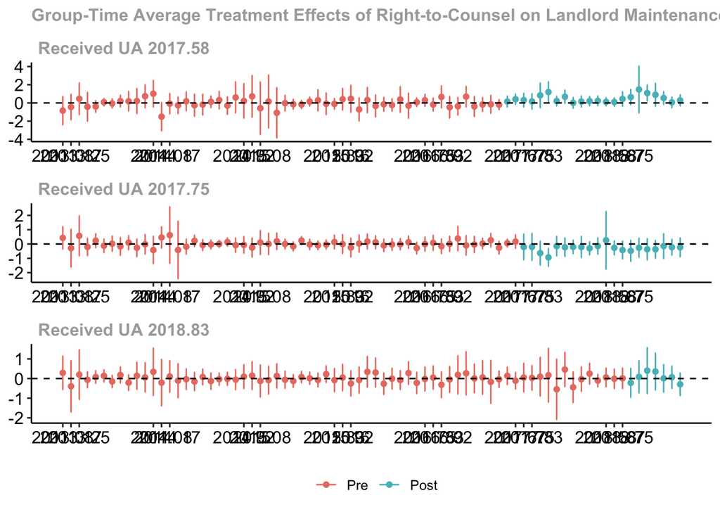

```r
ggdid(est_test,
      title = "Group-Time Average Treatment Effects of Right-to-Counsel on Landlord Maintenance Violations, 2013-2020 (No Covariates)",
      grtitle = "Received UA",
      xgap = 11)
```

Tract Event Study w/ Plot (No Covariates)

This aggregates the group-time ATEs

```r
event_study <- aggte(est_test, type = "dynamic")
summary(event_study)
```

```
##
## Call:
## aggte(MP = est_test, type = "dynamic")
##
## Reference: Callaway, Brantly and Pedro H.C. Sant'Anna.  "Difference-in-Differences with Multiple Time Periods." Journal of Econometrics, Vol. 225, No. 2, pp. 200-230, 2021. <https://doi.org/10.1016/j.jeconom.2020.12.001>, <https://arxiv.org/abs/1803.09015>
##
##
## Overall summary of ATT's based on event-study/dynamic aggregation:
##     ATT    Std. Error     [ 95%  Conf. Int.]
##  0.1581        0.0909    -0.0201      0.3364
##
##
## Dynamic Effects:
##  Event time Estimate Std. Error [95% Simult.  Conf. Band]
##       -5.75   0.2909     0.2642       -0.5633      1.1452
##       -5.66  -0.3957     0.4233       -1.7642      0.9728
##       -5.58   0.1977     0.3655       -0.9840      1.3795
##       -5.50  -0.0614     0.1230       -0.4589      0.3362
##       -5.41   0.0778     0.1031       -0.2555      0.4110
##       -5.33   0.1358     0.1003       -0.1883      0.4599
##       -5.25  -0.1508     0.0953       -0.4591      0.1574
##       -5.16   0.1804     0.1295       -0.2383      0.5992
##       -5.08  -0.2085     0.1225       -0.6046      0.1876
##       -5.00   0.1364     0.1938       -0.4902      0.7629
##       -4.91   0.0583     0.2270       -0.6756      0.7923
##       -4.83   0.3421     0.3233       -0.7033      1.3874
##       -4.75  -0.2095     0.3534       -1.3522      0.9331
##       -4.67   0.4276     0.2389       -0.3446      1.1999
##       -4.66   0.1045     0.2379       -0.6646      0.8737
##       -4.58  -0.1984     0.2313       -0.9462      0.5494
##       -4.50  -0.2374     0.2359       -1.0001      0.5254
##       -4.42  -0.2044     0.1906       -0.8206      0.4117
##       -4.41  -0.3372     0.2735       -1.2214      0.5471
##       -4.33   0.2901     0.2321       -0.4603      1.0405
##       -4.25  -0.2601     0.2099       -0.9388      0.4186
##       -4.17   0.0228     0.1641       -0.5077      0.5532
##       -4.16  -0.2539     0.1252       -0.6588      0.1510
##       -4.08  -0.0129     0.0763       -0.2596      0.2339
##       -4.00  -0.0159     0.0883       -0.3014      0.2695
##       -3.92  -0.2674     0.1968       -0.9036      0.3689
```

[output cut: 81 more lines]

```
##        1.17   0.1735     0.1793       -0.4060      0.7530
##        1.25   0.2625     0.2094       -0.4145      0.9396
##        1.33  -0.3697     0.1896       -0.9826      0.2433
##        1.34   1.4745     0.8066       -1.1332      4.0822
##        1.42   0.6224     0.1972       -0.0151      1.2599
##        1.50   0.4770     0.2545       -0.3458      1.2999
##        1.58  -0.2348     0.1933       -0.8595      0.3900
##        1.59   0.5442     0.2216       -0.1722      1.2606
##        1.67   0.0637     0.1785       -0.5134      0.6408
##        1.75   0.2858     0.1452       -0.1838      0.7554
## ---
## Signif. codes: `*' confidence band does not cover 0
##
## Control Group:  Not Yet Treated,  Anticipation Periods:  0
## Estimation Method:  Doubly Robust
```

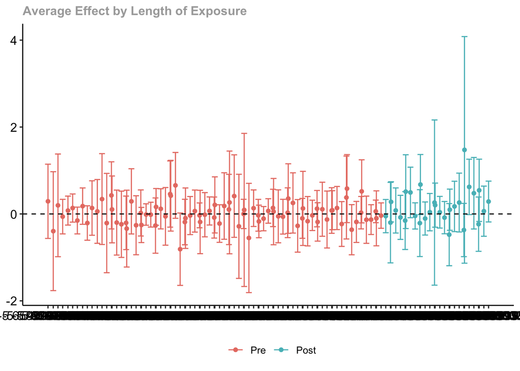

```r
ggdid(event_study)
```

Overall Effect of Participating in Treatment

```r
group_effects <- aggte(est_test, type = "group")
summary(group_effects)
```

```
##
## Call:
## aggte(MP = est_test, type = "group")
##
## Reference: Callaway, Brantly and Pedro H.C. Sant'Anna.  "Difference-in-Differences with Multiple Time Periods." Journal of Econometrics, Vol. 225, No. 2, pp. 200-230, 2021. <https://doi.org/10.1016/j.jeconom.2020.12.001>, <https://arxiv.org/abs/1803.09015>
##
##
## Overall summary of ATT's based on group/cohort aggregation:
##     ATT    Std. Error     [ 95%  Conf. Int.]
##  0.1467        0.0847    -0.0193      0.3128
##
##
## Group Effects:
##    Group Estimate Std. Error [95% Simult.  Conf. Band]
##  2017.58   0.4616     0.1227        0.1798      0.7434 *
##  2017.75  -0.2861     0.1448       -0.6185      0.0464
##  2018.83   0.0580     0.1694       -0.3311      0.4470
## ---
## Signif. codes: `*' confidence band does not cover 0
##
## Control Group:  Not Yet Treated,  Anticipation Periods:  0
## Estimation Method:  Doubly Robust
```

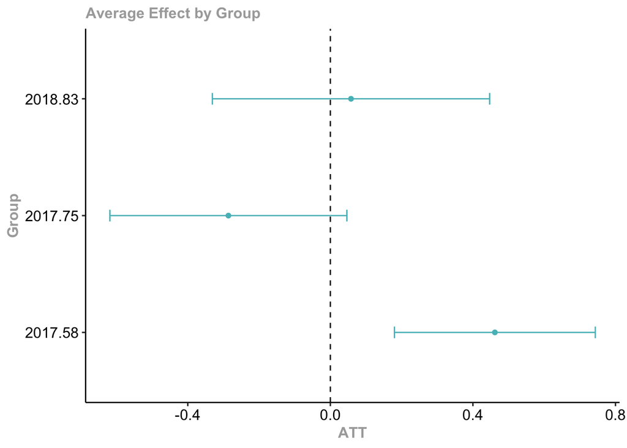

```r
ggdid(group_effects)
```

### CS-DiD: With covariates (Tract-Level)

In addition to introducing the race-based covariates above (i.e. “controlling for” race), we subset New York City census tracts within each treatment cohort by U.S. Census-defined racial majority. We theorize that treatment effects vary with racial segregation, and opt to subset since CS-DiD does not allow for interaction terms.

```r
maj_bl <- violations %>%
  filter(pct_bl_17 > 0.5) # 35,420 obs

maj_wh <- violations %>%
  filter(pct_wh_17 > 0.5) # 48,202 obs

maj_poc <- violations %>%
  filter(pct_wh_17 < 0.5) # 103,488 obs
```

#### Group-Time ATE, All Tracts, Controlling for Treatment Selection Criteria

```r
est_w_covars <- att_gt(yname = "n_violations_per_1k_units",
                       gname = "treat_yr_mo_num",
                       idname = "geoid",
                       tname = "inspection_yr_mo_num",
                       xformla = ~ evict_rate_17 + rs_rate_17 + pct_pov_17,
                       data = violations,
                       control_group = "notyettreated",
                       allow_unbalanced_panel = TRUE,
                       est_method = "dr")
summary(est_w_covars)
```

```
##
## Call:
## att_gt(yname = "n_violations_per_1k_units", tname = "inspection_yr_mo_num",
##     idname = "geoid", gname = "treat_yr_mo_num", xformla = ~evict_rate_17 +
##         rs_rate_17 + pct_pov_17, data = violations, allow_unbalanced_panel = TRUE,
##     control_group = "notyettreated", est_method = "dr")
##
## Reference: Callaway, Brantly and Pedro H.C. Sant'Anna.  "Difference-in-Differences with Multiple Time Periods." Journal of Econometrics, Vol. 225, No. 2, pp. 200-230, 2021. <https://doi.org/10.1016/j.jeconom.2020.12.001>, <https://arxiv.org/abs/1803.09015>
##
## Group-Time Average Treatment Effects:
##    Group    Time ATT(g,t) Std. Error [95% Simult.  Conf. Band]
##  2017.58 2013.08  -0.5523     0.2725       -1.4727      0.3682
##  2017.58 2013.17   0.0342     0.3065       -1.0011      1.0694
##  2017.58 2013.25   0.0598     0.2567       -0.8072      0.9268
##  2017.58 2013.33  -0.2313     0.1993       -0.9046      0.4421
##  2017.58 2013.42  -0.2310     0.1337       -0.6827      0.2207
##  2017.58 2013.50  -0.0034     0.1458       -0.4958      0.4889
##  2017.58 2013.58  -0.1148     0.1368       -0.5768      0.3472
##  2017.58 2013.67   0.2171     0.1332       -0.2329      0.6670
##  2017.58 2013.75   0.3499     0.3844       -0.9486      1.6484
##  2017.58 2013.83  -0.2385     0.3714       -1.4931      1.0161
##  2017.58 2013.92   0.5947     0.3020       -0.4254      1.6149
##  2017.58 2014.00   0.8881     0.3927       -0.4385      2.2146
##  2017.58 2014.08  -1.1584     0.4338       -2.6237      0.3068
##  2017.58 2014.17   0.1740     0.3146       -0.8886      1.2366
##  2017.58 2014.25  -0.3412     0.2685       -1.2482      0.5657
##  2017.58 2014.33   0.0678     0.2619       -0.8168      0.9523
##  2017.58 2014.42  -0.3517     0.2400       -1.1624      0.4590
##  2017.58 2014.50   0.1312     0.1537       -0.3882      0.6505
##  2017.58 2014.58  -0.0547     0.1722       -0.6366      0.5272
##  2017.58 2014.67   0.2611     0.2509       -0.5865      1.1087
##  2017.58 2014.75  -0.0976     0.2540       -0.9558      0.7605
##  2017.58 2014.83   0.2660     0.2975       -0.7388      1.2708
##  2017.58 2014.92  -0.2436     0.3223       -1.3324      0.8452
##  2017.58 2015.00   0.5427     0.4207       -0.8786      1.9640
##  2017.58 2015.08   0.0394     0.4377       -1.4393      1.5181
##  2017.58 2015.17  -0.4294     0.3214       -1.5151      0.6563
##  2017.58 2015.25  -0.1836     0.3314       -1.3031      0.9359
##  2017.58 2015.33  -0.0955     0.3423       -1.2519      1.0608
##  2017.58 2015.42  -0.0955     0.2202       -0.8393      0.6483
```

[output cut: 190 more lines]

```
##  2018.83 2018.67   0.0289     0.1633       -0.5226      0.5804
##  2018.83 2018.75   0.0417     0.1831       -0.5770      0.6603
##  2018.83 2018.83  -0.3039     0.2455       -1.1333      0.5255
##  2018.83 2018.92   0.0893     0.2697       -0.8218      1.0004
##  2018.83 2019.00   0.3181     0.3613       -0.9023      1.5385
##  2018.83 2019.08   0.4161     0.3062       -0.6182      1.4503
##  2018.83 2019.17  -0.0686     0.2161       -0.7985      0.6612
##  2018.83 2019.25  -0.0344     0.1898       -0.6757      0.6068
##  2018.83 2019.33  -0.3838     0.1966       -1.0480      0.2803
## ---
## Signif. codes: `*' confidence band does not cover 0
##
## P-value for pre-test of parallel trends assumption:  0
## Control Group:  Not Yet Treated,  Anticipation Periods:  0
## Estimation Method:  Doubly Robust
```

[figure not shown]

```r
ggdid(est_w_covars,
      title = "Figure 3. Tract-Level Group-Time ATE (With Covariates), 2013-2019",
      grtitle = "Received UA",
      xgap = 12,
      theming = FALSE) +
  theme_ipsum_rc(grid = FALSE, ticks = TRUE) +
  scale_x_continuous(breaks = seq(1,77,6),
                     labels = c("Jan 2013",
                                "Jul 2013",
                                "Jan 2014",
                                "Jul 2014",
                                "Jan 2015",
                                "Jul 2015",
                                "Jan 2016",
                                "Jul 2016",
                                "Jan 2017",
                                "Jul 2017",
                                "Jan 2018",
                                "Jul 2018",
                                "Jan 2019")) +
  theme(legend.position = "top",
        axis.text.x = element_text(angle = 45,
                                   margin = margin(t = 20)))
```

#### Dynamic Event Study with Plot (All Tracts)

```r
group_effects <- aggte(est_w_covars, type = "dynamic")
summary(group_effects)
```

```
##
## Call:
## aggte(MP = est_w_covars, type = "dynamic")
##
## Reference: Callaway, Brantly and Pedro H.C. Sant'Anna.  "Difference-in-Differences with Multiple Time Periods." Journal of Econometrics, Vol. 225, No. 2, pp. 200-230, 2021. <https://doi.org/10.1016/j.jeconom.2020.12.001>, <https://arxiv.org/abs/1803.09015>
##
##
## Overall summary of ATT's based on event-study/dynamic aggregation:
##     ATT    Std. Error     [ 95%  Conf. Int.]
##  0.1008        0.0953    -0.0859      0.2875
##
##
## Dynamic Effects:
##  Event time Estimate Std. Error [95% Simult.  Conf. Band]
##       -5.75   0.0256     0.2232       -0.7019      0.7531
##       -5.66  -0.0212     0.2251       -0.7549      0.7125
##       -5.58  -0.1245     0.1667       -0.6678      0.4189
##       -5.50  -0.0447     0.1259       -0.4552      0.3658
##       -5.41   0.0646     0.1148       -0.3097      0.4390
##       -5.33   0.1453     0.1056       -0.1989      0.4894
##       -5.25  -0.1238     0.1067       -0.4715      0.2239
##       -5.16   0.2038     0.1375       -0.2445      0.6522
##       -5.08  -0.2266     0.1425       -0.6912      0.2380
##       -5.00   0.2044     0.2175       -0.5048      0.9136
##       -4.91   0.0754     0.2359       -0.6938      0.8446
##       -4.83   0.4046     0.3699       -0.8012      1.6104
##       -4.75  -0.2959     0.3892       -1.5648      0.9730
##       -4.67   0.2698     0.2250       -0.4637      1.0034
##       -4.66   0.1340     0.2661       -0.7335      1.0014
##       -4.58  -0.0079     0.1890       -0.6240      0.6082
##       -4.50  -0.2453     0.1526       -0.7429      0.2523
##       -4.42  -0.1001     0.1659       -0.6410      0.4409
##       -4.41  -0.0540     0.1797       -0.6398      0.5318
##       -4.33   0.1023     0.1242       -0.3028      0.5073
##       -4.25  -0.1526     0.1057       -0.4973      0.1920
##       -4.17   0.0495     0.1958       -0.5889      0.6879
##       -4.16  -0.1670     0.0957       -0.4789      0.1449
##       -4.08  -0.0710     0.0827       -0.3407      0.1988
##       -4.00   0.0182     0.0863       -0.2632      0.2997
##       -3.92  -0.1724     0.2340       -0.9355      0.5906
```

[output cut: 81 more lines]

```
##        1.17   0.2187     0.2045       -0.4479      0.8853
##        1.25   0.1374     0.1947       -0.4973      0.7721
##        1.33  -0.2991     0.2168       -1.0058      0.4076
##        1.34   0.6649     0.2470       -0.1402      1.4701
##        1.42   0.4551     0.1997       -0.1959      1.1061
##        1.50   0.2624     0.1719       -0.2981      0.8230
##        1.58  -0.2167     0.2323       -0.9741      0.5407
##        1.59   0.4828     0.1890       -0.1333      1.0990
##        1.67   0.1004     0.1853       -0.5037      0.7044
##        1.75   0.3349     0.1848       -0.2675      0.9373
## ---
## Signif. codes: `*' confidence band does not cover 0
##
## Control Group:  Not Yet Treated,  Anticipation Periods:  0
## Estimation Method:  Doubly Robust
```

[figure not shown]

```r
ggdid(group_effects,
      title = "Fig. 4. Average Effect by Tracts' Length of Exposure",
      xlab = "Pre/Post Treatment Time in Months",
      xgap = 12,
      theming = FALSE) +
  theme_ipsum_rc(grid = F)
```

#### Overall Effect of Participating in Treatment (All Tracts)

```r
group_effects <- aggte(est_w_covars, type = "group")
summary(group_effects) # Wave 1 has a statistically significant bump in hhw violations
```

```
##
## Call:
## aggte(MP = est_w_covars, type = "group")
##
## Reference: Callaway, Brantly and Pedro H.C. Sant'Anna.  "Difference-in-Differences with Multiple Time Periods." Journal of Econometrics, Vol. 225, No. 2, pp. 200-230, 2021. <https://doi.org/10.1016/j.jeconom.2020.12.001>, <https://arxiv.org/abs/1803.09015>
##
##
## Overall summary of ATT's based on group/cohort aggregation:
##     ATT    Std. Error     [ 95%  Conf. Int.]
##  0.0859        0.0881    -0.0867      0.2585
##
##
## Group Effects:
##    Group Estimate Std. Error [95% Simult.  Conf. Band]
##  2017.58   0.3442     0.1176        0.0758      0.6126 *
##  2017.75  -0.2471     0.1623       -0.6176      0.1233
##  2018.83   0.0047     0.1892       -0.4270      0.4364
## ---
## Signif. codes: `*' confidence band does not cover 0
##
## Control Group:  Not Yet Treated,  Anticipation Periods:  0
## Estimation Method:  Doubly Robust
```

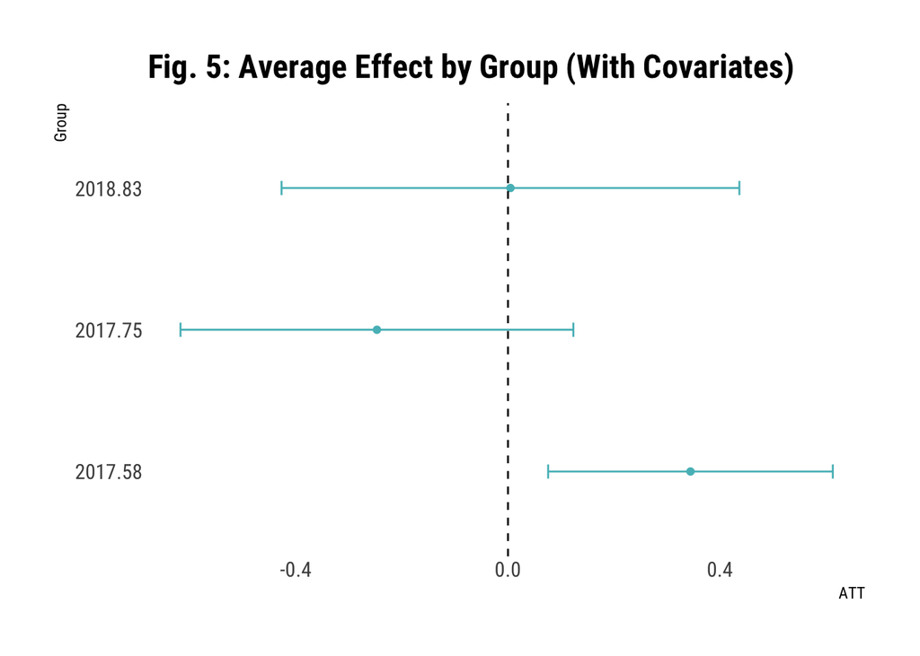

```r
ggdid(group_effects,
      title = "Fig. 5: Average Effect by Group (With Covariates)",
      theming = FALSE) +
  theme_ipsum_rc(grid = F) +
  theme(legend.position = "none")
```

#### CS-DiD, Subset of Tracts With >50% Black Renter-Occupied Householders

```r
est_all <- att_gt(yname = "n_violations_per_1k_units",
                       gname = "treat_yr_mo_num",
                       idname = "geoid",
                       tname = "inspection_yr_mo_num",
                       xformla = ~ evict_rate_17 + rs_rate_17 + pct_pov_17,
                       data = violations,
                       control_group = "notyettreated",
                       allow_unbalanced_panel = TRUE,
                       est_method = "dr")
group_fx_all <- aggte(est_all, type = "group")
summary(group_fx_all)
```

```
##
## Call:
## aggte(MP = est_all, type = "group")
##
## Reference: Callaway, Brantly and Pedro H.C. Sant'Anna.  "Difference-in-Differences with Multiple Time Periods." Journal of Econometrics, Vol. 225, No. 2, pp. 200-230, 2021. <https://doi.org/10.1016/j.jeconom.2020.12.001>, <https://arxiv.org/abs/1803.09015>
##
##
## Overall summary of ATT's based on group/cohort aggregation:
##     ATT    Std. Error     [ 95%  Conf. Int.]
##  0.0859        0.0864    -0.0834      0.2552
##
##
## Group Effects:
##    Group Estimate Std. Error [95% Simult.  Conf. Band]
##  2017.58   0.3442     0.1227        0.0723      0.6162 *
##  2017.75  -0.2471     0.1651       -0.6131      0.1188
##  2018.83   0.0047     0.1910       -0.4188      0.4282
## ---
## Signif. codes: `*' confidence band does not cover 0
##
## Control Group:  Not Yet Treated,  Anticipation Periods:  0
## Estimation Method:  Doubly Robust
```

```r
est_w_race_covar <- att_gt(yname = "n_violations_per_1k_units",
                       gname = "treat_yr_mo_num",
                       idname = "geoid",
                       tname = "inspection_yr_mo_num",
                       xformla = ~ evict_rate_17 + rs_rate_17 + pct_pov_17 + pct_bl_17,
                       data = violations,
                       control_group = "notyettreated",
                       allow_unbalanced_panel = TRUE,
                       est_method = "dr")
group_fx_w_race_covar <- aggte(est_w_race_covar, type = "group")
summary(group_fx_w_race_covar)
```

```
##
## Call:
## aggte(MP = est_w_race_covar, type = "group")
##
## Reference: Callaway, Brantly and Pedro H.C. Sant'Anna.  "Difference-in-Differences with Multiple Time Periods." Journal of Econometrics, Vol. 225, No. 2, pp. 200-230, 2021. <https://doi.org/10.1016/j.jeconom.2020.12.001>, <https://arxiv.org/abs/1803.09015>
##
##
## Overall summary of ATT's based on group/cohort aggregation:
##     ATT    Std. Error     [ 95%  Conf. Int.]
##  0.0422         0.093      -0.14      0.2245
##
##
## Group Effects:
##    Group Estimate Std. Error [95% Simult.  Conf. Band]
##  2017.58   0.2309     0.1227       -0.0585      0.5203
##  2017.75  -0.2334     0.1560       -0.6013      0.1346
##  2018.83   0.0110     0.2210       -0.5101      0.5320
## ---
## Signif. codes: `*' confidence band does not cover 0
##
## Control Group:  Not Yet Treated,  Anticipation Periods:  0
## Estimation Method:  Doubly Robust
```

```r
est_bl <- att_gt(yname = "n_violations_per_1k_units",
                       gname = "treat_yr_mo_num",
                       idname = "geoid",
                       tname = "inspection_yr_mo_num",
                       xformla = ~ evict_rate_17 + rs_rate_17 + pct_pov_17,
                       data = maj_bl,
                       control_group = "notyettreated",
                       allow_unbalanced_panel = TRUE,
                       est_method = "dr")
group_fx_bl <- aggte(est_bl, type = "group")
summary(group_fx_bl)
```

```
##
## Call:
## aggte(MP = est_bl, type = "group")
##
## Reference: Callaway, Brantly and Pedro H.C. Sant'Anna.  "Difference-in-Differences with Multiple Time Periods." Journal of Econometrics, Vol. 225, No. 2, pp. 200-230, 2021. <https://doi.org/10.1016/j.jeconom.2020.12.001>, <https://arxiv.org/abs/1803.09015>
##
##
## Overall summary of ATT's based on group/cohort aggregation:
##     ATT    Std. Error     [ 95%  Conf. Int.]
##  0.1336        0.1621    -0.1841      0.4513
##
##
## Group Effects:
##    Group Estimate Std. Error [95% Simult.  Conf. Band]
##  2017.58   0.1108     0.1921       -0.3326      0.5542
##  2017.75   0.2583     0.2579       -0.3369      0.8534
##  2018.83   0.1113     0.3511       -0.6991      0.9216
## ---
## Signif. codes: `*' confidence band does not cover 0
##
## Control Group:  Not Yet Treated,  Anticipation Periods:  0
## Estimation Method:  Doubly Robust
```

Side-by-side Table

```r
t4a <- tidy(group_fx_all) %>%
  select(-c(type, term, point.conf.low, point.conf.high)) %>%
  mutate(group = str_replace_all(group, c("Average" = "All Groups", "2017.58" = "Cohort 1", "2017.75" = "Cohort 2", "2018.83" = "Cohort 3")))

t4b <- tidy(group_fx_bl) %>%
  select(-c(type, term, point.conf.low, point.conf.high)) %>%
  mutate(group = str_replace_all(group, c("Average" = "All Groups", "2017.58" = "Cohort 1", "2017.75" = "Cohort 2", "2018.83" = "Cohort 3")))

t4c <- tidy(group_fx_w_race_covar) %>%
  select(-c(type, term, point.conf.low, point.conf.high)) %>%
  mutate(group = str_replace_all(group, c("Average" = "All Groups", "2017.58" = "Cohort 1", "2017.75" = "Cohort 2", "2018.83" = "Cohort 3")))
```

Table 5

```r
knitr::kables(
  list(
    kable(
      t4a,
      col.names = NULL,
      digits = 4,
      valign = 't') %>%
      add_header_above(c('Group', 'ATT', 'Std. Error', '95% Confidence Band' = 2)) %>%
      add_header_above(c('Covariates: Eviction Rate, Rent Stabilization Rate, Poverty Rate' = 4)) %>%
      add_header_above(c(' ', 'All Tract Neighborhoods' = 3)) %>%
      add_footnote(c("Signif. codes: '*' = confidence band does not cover 0", "Control Groups: Not Yet Treated, Anticipation Periods: 0", "Estimation Method: Doubly Robust"), notation = "none") %>%
      kable_styling(),
    kable(t4c,
          col.names = NULL,
          digits = 4,
          valign = 't') %>%
      add_header_above(c('Group', 'ATT', 'Std. Error', '95% Confidence Band' = 2)) %>%
     add_header_above(c('Covariates: Eviction Rate, Rent Stabilization Rate, Poverty Rate, % Black Renter Householders' = 4)) %>%
      add_header_above(c(' ', 'All Tract Neighborhoods' = 3)) %>%
      kable_styling(),
    kable(t4b,
          col.names = NULL,
          digits = 4,
          valign = 't') %>%
      add_header_above(c('Group', 'ATT', 'Std. Error', '95% Confidence Band' = 2)) %>%
      add_header_above(c('Covariates: Eviction Rate, Rent Stabilization Rate, Poverty Rate' = 4)) %>%
      add_header_above(c(' ', '>50% Black Tract Neighborhoods' = 3)) %>%
      kable_styling()

  ),
  caption = 'Table 5. Aggregated Group-Specific Treatment Effects'
) %>%
  kable_styling(full_width = F,
                  html_font = "Roboto Condensed")
```

Table 5. Aggregated Group-Specific Treatment Effects

| Covariates: Eviction Rate, Rent Stabilization Rate, Poverty Rate Group | All Tract Neighborhoods Covariates: Eviction Rate, Rent Stabilization Rate, Poverty Rate ATT | All Tract Neighborhoods Covariates: Eviction Rate, Rent Stabilization Rate, Poverty Rate Std. Error | All Tract Neighborhoods Covariates: Eviction Rate, Rent Stabilization Rate, Poverty Rate 95% Confidence Band | 95% Confidence Band |
| --- | --- | --- | --- | --- |
| All Groups | 0.0859 | 0.0864 | -0.0834 | 0.2552 |
| Cohort 1 | 0.3442 | 0.1227 | 0.0723 | 0.6162 |
| Cohort 2 | -0.2471 | 0.1651 | -0.6131 | 0.1188 |
| Cohort 3 | 0.0047 | 0.1910 | -0.4188 | 0.4282 |

Signif. codes: ’*’ = confidence band does not cover 0  
Control Groups: Not Yet Treated, Anticipation Periods: 0  
Estimation Method: Doubly Robust

| Covariates: Eviction Rate, Rent Stabilization Rate, Poverty Rate, % Black Renter Householders Group | All Tract Neighborhoods Covariates: Eviction Rate, Rent Stabilization Rate, Poverty Rate, % Black Renter Householders ATT | All Tract Neighborhoods Covariates: Eviction Rate, Rent Stabilization Rate, Poverty Rate, % Black Renter Householders Std. Error | All Tract Neighborhoods Covariates: Eviction Rate, Rent Stabilization Rate, Poverty Rate, % Black Renter Householders 95% Confidence Band | 95% Confidence Band |
| --- | --- | --- | --- | --- |
| All Groups | 0.0422 | 0.0930 | -0.1400 | 0.2245 |
| Cohort 1 | 0.2309 | 0.1227 | -0.0585 | 0.5203 |
| Cohort 2 | -0.2334 | 0.1560 | -0.6013 | 0.1346 |
| Cohort 3 | 0.0110 | 0.2210 | -0.5101 | 0.5320 |

| Covariates: Eviction Rate, Rent Stabilization Rate, Poverty Rate Group | >50% Black Tract Neighborhoods Covariates: Eviction Rate, Rent Stabilization Rate, Poverty Rate ATT | >50% Black Tract Neighborhoods Covariates: Eviction Rate, Rent Stabilization Rate, Poverty Rate Std. Error | >50% Black Tract Neighborhoods Covariates: Eviction Rate, Rent Stabilization Rate, Poverty Rate 95% Confidence Band | 95% Confidence Band |
| --- | --- | --- | --- | --- |
| All Groups | 0.1336 | 0.1621 | -0.1841 | 0.4513 |
| Cohort 1 | 0.1108 | 0.1921 | -0.3326 | 0.5542 |
| Cohort 2 | 0.2583 | 0.2579 | -0.3369 | 0.8534 |
| Cohort 3 | 0.1113 | 0.3511 | -0.6991 | 0.9216 |

## Tract-Level Parallel Trends “Test”

Callaway and Sant’Anna propose the Cramer von Mises or Kolgorov-Smirnov-type integrated moments test as one tool for assessing whether the conditional parallel trends assumption might hold for all groups in all pre-treatment periods. See https://search.r-project.org/CRAN/refmans/did/html/conditional_did_pretest.html and Section 4 of Callaway & Sant’Anna (2020).

Since these tests are extremely memory-heavy and take approximately three to four hours to run per model (at the time of this writing), we include just the code used to generate them here. See also our Github repository’s scripts/09_cvm.tests.R

```r
cdp_tract <- conditional_did_pretest(yname = "n_violations_per_1k_units",
                               tname = "inspection_yr_mo_num",
                               idname = "geoid",
                               gname = "treat_yr_mo_num",
                               control_group = "notyettreated",
                               xformla = ~ evict_rate_17 + rs_rate_17 + pct_pov_17,
                               data = violations)
```

```r
cdp_tract <- readRDS("~/Dropbox/Mac/Desktop/nyu-capstone-F23-S24/data_build/cdp_tract.Rds")
summary(cdp_tract)
```

```
## Reference: Callaway, Brantly and Pedro H.C. Sant'Anna.  "Difference-in-Differences with Multiple Time Periods." Journal of Econometrics, Vol. 225, No. 2, pp. 200-230, 2021. <https://doi.org/10.1016/j.jeconom.2020.12.001>, <https://arxiv.org/abs/1803.09015>
## Cramer von Mises:
##   Test Statistic:  10826.66
##   Critical Value:  1172.186
##   P-value       :  0
##
## Clustering on   :  ,
## X formula       :  ~ evict_rate_17 + rs_rate_17 + pct_pov_17
```

```r
cdp_tract_maj_bl <- conditional_did_pretest(yname = "n_violations_per_1k_units",
                               tname = "inspection_yr_mo_num",
                               idname = "geoid",
                               gname = "treat_yr_mo_num",
                               control_group = "notyettreated",
                               xformla = ~ evict_rate_17 + rs_rate_17 + pct_pov_17,
                               data = maj_bl)
```

```r
cdp_tract_maj_bl <- readRDS("~/Dropbox/Mac/Desktop/nyu-capstone-F23-S24/data_build/cdp_tract_maj_bl.Rds")
summary(cdp_tract_maj_bl)
```

```
## Reference: Callaway, Brantly and Pedro H.C. Sant'Anna.  "Difference-in-Differences with Multiple Time Periods." Journal of Econometrics, Vol. 225, No. 2, pp. 200-230, 2021. <https://doi.org/10.1016/j.jeconom.2020.12.001>, <https://arxiv.org/abs/1803.09015>
## Cramer von Mises:
##   Test Statistic:  1846.683
##   Critical Value:  1012.418
##   P-value       :  0
##
## Clustering on   :  ,
## X formula       :  ~ evict_rate_17 + rs_rate_17 + pct_pov_17
```

```r
cdp_tract_pct_bl <- conditional_did_pretest(yname = "n_violations_per_1k_units",
                               tname = "inspection_yr_mo_num",
                               idname = "geoid",
                               gname = "treat_yr_mo_num",
                               control_group = "notyettreated",
                               xformla = ~ evict_rate_17 + rs_rate_17 + pct_pov_17 + pct_bl_17,
                               data = violations)
```

```r
cdp_tract_pct_bl <- readRDS("~/Dropbox/Mac/Desktop/nyu-capstone-F23-S24/data_build/cdp_tract_pct_bl.Rds")
summary(cdp_tract_pct_bl)
```

```
## Reference: Callaway, Brantly and Pedro H.C. Sant'Anna.  "Difference-in-Differences with Multiple Time Periods." Journal of Econometrics, Vol. 225, No. 2, pp. 200-230, 2021. <https://doi.org/10.1016/j.jeconom.2020.12.001>, <https://arxiv.org/abs/1803.09015>
## Cramer von Mises:
##   Test Statistic:  4519.815
##   Critical Value:  660.7752
##   P-value       :  0
##
## Clustering on   :  ,
## X formula       :  ~ evict_rate_17 + rs_rate_17 + pct_pov_17 + pct_bl_17
```

```r
cdp_tract_pct_wh <- conditional_did_pretest(yname = "n_violations_per_1k_units",
                               tname = "inspection_yr_mo_num",
                               idname = "geoid",
                               gname = "treat_yr_mo_num",
                               control_group = "notyettreated",
                               xformla = ~ evict_rate_17 + rs_rate_17 + pct_pov_17 + pct_wh_17,
                               data = violations)
```

```r
cdp_tract_pct_wh <- readRDS("~/Dropbox/Mac/Desktop/nyu-capstone-F23-S24/data_build/cdp_tract_pct_wh.Rds")
summary(cdp_tract_pct_wh)
```

```
## Reference: Callaway, Brantly and Pedro H.C. Sant'Anna.  "Difference-in-Differences with Multiple Time Periods." Journal of Econometrics, Vol. 225, No. 2, pp. 200-230, 2021. <https://doi.org/10.1016/j.jeconom.2020.12.001>, <https://arxiv.org/abs/1803.09015>
## Cramer von Mises:
##   Test Statistic:  2971.1
##   Critical Value:  370.4699
##   P-value       :  0
##
## Clustering on   :  ,
## X formula       :  ~ evict_rate_17 + rs_rate_17 + pct_pov_17 + pct_wh_17
```

Combine into single results output table

```r
cdp_three_table <- as.data.frame(do.call(cbind, cdp_tract_pct_bl)) %>%
  select(xformla, CvM, CvMcval, CvMpval) %>%
  distinct() %>%
  slice(2)

cdp_four_table <- as.data.frame(do.call(cbind, cdp_tract_maj_bl)) %>%
  select(xformla, CvM, CvMcval, CvMpval) %>%
  distinct() %>%
  slice(2)

cdp_table <- as.data.frame(do.call(cbind, cdp_tract)) %>%
  select(xformla, CvM, CvMcval, CvMpval) %>%
  distinct() %>%
  slice(2) %>%
  bind_rows(cdp_three_table, cdp_four_table) %>%
  mutate(Covariates = c('[All Tracts] 2017 eviction rate + 2017 rent stabilization rate + 2017 poverty rate',
                        '[All Tracts] 2017 eviction rate + 2017 rent stabilization rate + 2017 poverty rate + 2017 proportion Black renters',
                        '[Subset of Majority-Black Census Tracts] 2017 eviction rate + 2017 rent stabilization rate + 2017 poverty rate'), .before = xformla) %>%
  select(-xformla)
```

```r
cdp_table %>%
  kable(
    digits = 2,
    caption = 'Table 4. Cramer von Mises Test Results',
    col.names = c('Covariates', 'Test Statistic', 'Critical Value', 'P-Value'),
    align = "l") %>%
  add_footnote(c("Callaway and Sant'Anna propose the Cramer von Mises or Kolgorov-Smirnov-type integrated moments test as one tool for assessing whether the conditional parallel trends assumption might hold for all groups in all pre-treatment periods. See https://search.r-project.org/CRAN/refmans/did/html/conditional_did_pretest.html and Section 4 of Callaway & Sant'Anna (2020)."), notation = "none") %>%
  kable_styling(full_width = F, html_font = "Roboto Condensed")
```

Table 4. Cramer von Mises Test Results

| Covariates | Test Statistic | Critical Value | P-Value |
| --- | --- | --- | --- |
| [All Tracts] 2017 eviction rate + 2017 rent stabilization rate + 2017 poverty rate | 10826.66 | 1172.186 | 0 |
| [All Tracts] 2017 eviction rate + 2017 rent stabilization rate + 2017 poverty rate + 2017 proportion Black renters | 4519.815 | 660.7752 | 0 |
| [Subset of Majority-Black Census Tracts] 2017 eviction rate + 2017 rent stabilization rate + 2017 poverty rate | 1846.683 | 1012.418 | 0 |

Callaway and Sant’Anna propose the Cramer von Mises or Kolgorov-Smirnov-type integrated moments test as one tool for assessing whether the conditional parallel trends assumption might hold for all groups in all pre-treatment periods. See https://search.r-project.org/CRAN/refmans/did/html/conditional_did_pretest.html and Section 4 of Callaway & Sant’Anna (2020).